# 20250530_tscan_trajectories

Stephanie Hickey

2025-11-06

#### Lab: Weiming Li

#### Project: BCC125_sea_lamprey_scRNA

```r
# Load libraries
library(dplyr)
library(ggplot2)
library(SingleCellExperiment)
library(scater)
library(scran)
library(patchwork)
library(pheatmap)
library(RColorBrewer)
library(readxl)
library(monocle3)
library(batchelor)
library(BiocSingular)
library(DT)
library(TSCAN)
library(rtracklayer)
source(paste0(params$project_dir, "/src/scRNA_seq_functions.R"))
```

```r
# Set Paths
results_dir = paste0(params$project_dir, "/results/20250930")
# results_dir = "/mnt/ufs18/rs-013/bioinformaticsCore/projects/chong_davidson/BCC125_sea_lamprey_scRNA/results/20250930"
data_dir = paste0(params$project_dir, "/data")
# data_dir = "/mnt/ufs18/rs-013/bioinformaticsCore/projects/chong_davidson/BCC125_sea_lamprey_scRNA/data"
```

# Collect individual samples into one object

```r
# Load QC'd data
sample_dirs = list.dirs(data_dir, full.names = TRUE, recursive = FALSE)
sample_names = basename(sample_dirs)

cds_list = list()

for(i in 1:length(sample_dirs)){

  cds_list[[i]] = readRDS(paste0(sample_dirs[i],
                                 "/",
                                 sample_names[i],
                                 "_cds_mito_filter.Rds"))
}

names(cds_list) = sample_names
all.sce = list()

# cds to sce
for (cds in names(cds_list)){

  raw_counts = counts(cds_list[[cds]])
  all.sce[[cds]] =
    SingleCellExperiment(list(counts=raw_counts),
                         colData=cds_list[[cds]]@colData)
  all.sce[[cds]]@colData$sample = cds

}

# https://bioconductor.org/books/3.14/OSCA.multisample/human-pbmcs-10x-genomics.html
# normalization, feature selection, dim reduction
all.sce <- lapply(all.sce, logNormCounts)
all.dec <- lapply(all.sce, modelGeneVar)
all.hvgs <- lapply(all.dec, getTopHVGs, prop=0.1)
all.sce <- mapply(FUN=runPCA, x=all.sce, subset_row=all.hvgs)

saveRDS(all.sce, file=paste0(results_dir, "/all.sce.Rds"))
```

# Make info per sample table

```r
df_list = list()

for(samp in names(all.sce)){

  # number of cells
  ncells = ncol(all.sce[[samp]])
  # mean counts
  med_counts = round(median(colData(all.sce[[samp]])$sum))
  # mean genes detected
  med_genes = round(median(colData(all.sce[[samp]])$detected))
  # mean percent mitochondria
  med_mito = median(colData(all.sce[[samp]])$subsets_Mito_percent)
  med_mito = round(med_mito, digits = 2)

  df_list[[samp]] =
    data.frame(Sample = samp,
              nCells = ncells,
              medianCounts = med_counts,
              medianGenesDetected = med_genes,
              medianPercentMitoReads = med_mito
              )
}

df_all = do.call(rbind,df_list)
write.csv(df_all, file = paste0(results_dir, "/median_stats.csv"))

datatable(df_all, rownames = FALSE)
```

| Sample | nCells | medianCounts | medianGenesDetected | medianPercentMitoReads |
| --- | --- | --- | --- | --- |
| TF_C00004337 | 13803 | 6066 | 1287 | 0.67 |
| TM_C00004374 | 18324 | 10532 | 2141 | 2.19 |
| UND1_C00004336 | 17186 | 5721 | 1366 | 1.3 |
| UND2_C00004362 | 17454 | 6396 | 1431 | 1.29 |

# Merge samples, removing sample batch effect

```r
# integration
# Intersecting the common genes.
universe <- Reduce(intersect, lapply(all.sce, rownames))
all.sce2 <- lapply(all.sce, "[", i=universe,)
all.dec2 <- lapply(all.dec, "[", i=universe,)

# Renormalizing to adjust for differences in depth.
normed.sce <- do.call(multiBatchNorm, all.sce2)

# Identifying a set of HVGs using stats from all batches.
combined.dec <- do.call(combineVar, all.dec2)
combined.hvg <- getTopHVGs(combined.dec, n=5000)

set.seed(1)
merged.sce <- do.call(fastMNN, c(normed.sce,
    list(subset.row=combined.hvg, BSPARAM=RandomParam())))

# clustering in corrected space
g <- buildSNNGraph(merged.sce, use.dimred="corrected", k=30)
set.seed(1)
colLabels(merged.sce) <- factor(igraph::cluster_louvain(g)$membership)

set.seed(1)
merged.sce <- runUMAP(merged.sce, dimred="corrected")
set.seed(1)
merged.sce <- runTSNE(merged.sce, dimred="corrected")

saveRDS(merged.sce, file = paste0(results_dir, "/merged.sce.Rds"))
```

The plot below shows the merged data in TSNE space separated by sample.

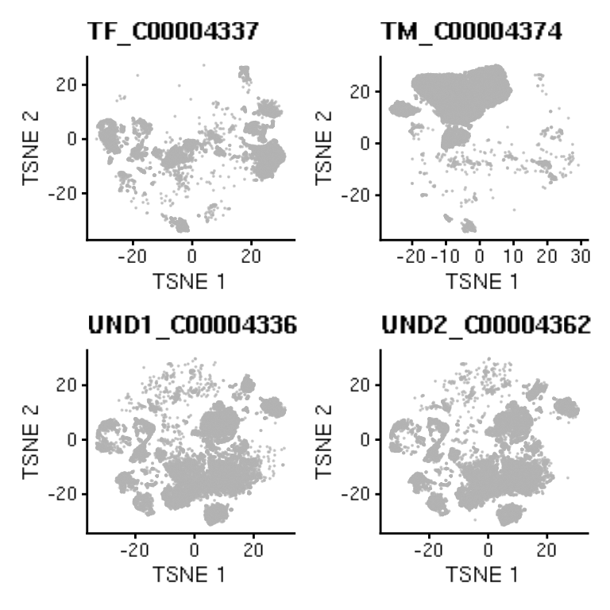

```r
# plot TSNE

p <- lapply(unique(merged.sce$batch), function(f) {
  sce.f = merged.sce[, which(merged.sce$batch == f)]
  plotTSNE(sce.f, point_size = .05) + ggtitle(f)
})

wrap_plots(p, ncol = 2)
```

This plot shows clusters identified using the “scatter” package in the batch corrected expression space.

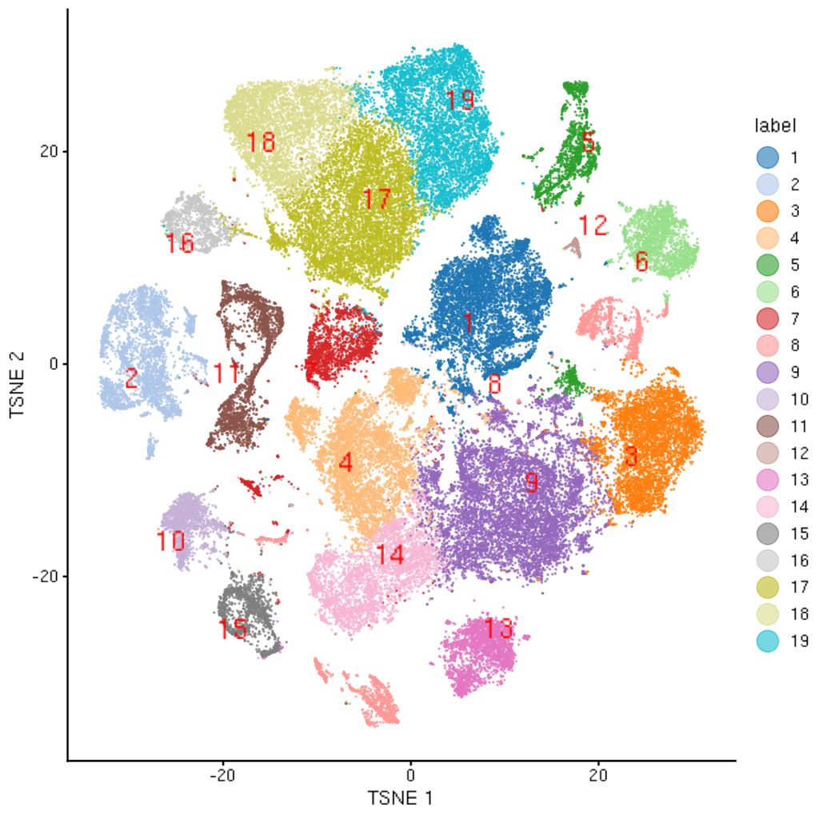

```r
plotTSNE(merged.sce, colour_by="label", text_by="label", text_colour="red", point_size = .05) +
  guides(color = guide_legend(override.aes = list(size=5)))
```

```r
#ggsave(file = paste0(results_dir, "/all_cells_tsne.png"))
```

This plot shows the proportion of cells from each sample within each new cluster.

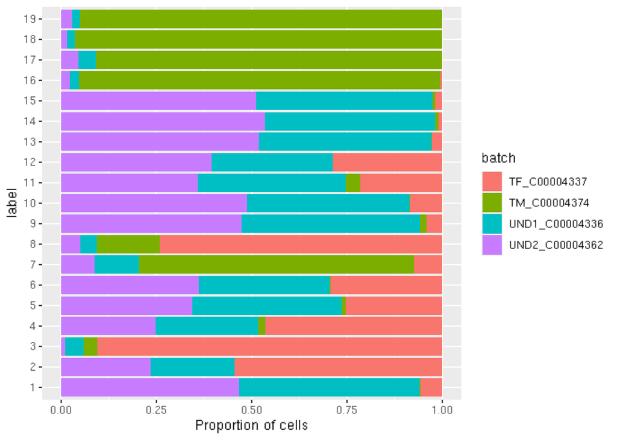

```r
meta_df = as.data.frame(colData(merged.sce))

sample_tally =
  meta_df %>%
  group_by(label, batch) %>%
  tally()

ggplot(sample_tally, aes(fill=batch, y=label, x=n)) +
    geom_bar(position="fill", stat="identity") +
    xlab("Proportion of cells")
```

## Plot known cell-type markers

In each cell, the expression of genes within each group are summed. In the plots, higher expression is a brighter color. Expression is scaled to percent of maximum expression.

Use known markers unique to each cell type:

```r
# load known marker genes
library(readr)
chung_davidson_cell_type_markers <- read_csv(paste0(data_dir, "/chung_davidson_cell_type_markers.csv"))
chung_davidson_cell_type_markers =
  chung_davidson_cell_type_markers %>%
  select(-GeneName)

chung_davidson_unique =
  chung_davidson_cell_type_markers %>%
  group_by(Gene) %>%
  tally() %>%
  filter(n == 1) %>%
  select(Gene) %>%
  left_join(chung_davidson_cell_type_markers)

datatable(chung_davidson_unique, filter = "top", rownames = FALSE)
```

| Gene | Group |
| --- | --- |
| ARPC2 | Male germ cells |
| Boll | Migrating germ cells |
| CCNB2 | Mitotic Spermatogonia |
| CDH1 | Germline stem cells |
| CDH5 | Primordial Germ Cells (PGC |
| CNOT1 | Primordial Germ Cells (PGC |
| CNOT7 | Primordial Germ Cells (PGC |
| DCST1 | Primary spermatocyte |
| DCST2 | Primary spermatocyte |
| DMC1 | Meiotic Spermatogonia |

[output cut: 117 more lines]

```r
# make cds for plotting with monocle
# Intersecting the common genes.
all.dec <- lapply(all.sce, modelGeneVar)
universe <- Reduce(intersect, lapply(all.sce, rownames))
all.sce2 <- lapply(all.sce, "[", i=universe,)
all.dec2 <- lapply(all.dec, "[", i=universe,)

all.sce2[["TM_C00004374"]]@colData$cluster="noclust"

# uncorrected gene expression
combined.sce <- do.call(cbind, all.sce2)
saveRDS(combined.sce, file = paste0(results_dir, "/combined.sce.Rds"))

merged.cds <- new_cell_data_set(counts(combined.sce),
                                cell_metadata = merged.sce@colData)

reducedDims(merged.cds)$UMAP <- reducedDims(merged.sce)$UMAP
reducedDims(merged.cds)$tSNE <- reducedDims(merged.sce)$TSNE
rowData(merged.cds)$gene_short_name = row.names(merged.cds)

# saveRDS(merged.cds, file = paste0(results_dir, "/merged.cds.Rds"))
```

Plot for early cell markers.

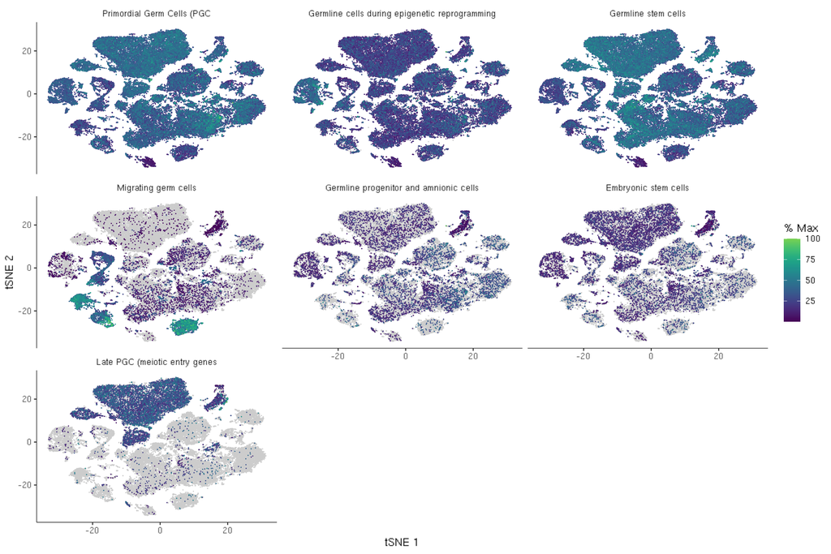

```r
plot_cells(merged.cds, reduction_method = "tSNE",
           genes=chung_davidson_unique %>%
             filter(Group %in% c("Germline cells during epigenetic reprogramming",
                                 "Germline stem cells",
                                 "Embryonic stem cells",
                                 "Germline progenitor and amnionic cells",
                                 "Primordial Germ Cells (PGC",
                                 "Migrating germ cells",
                                 "Late PGC (meiotic entry genes")))
```

Female cell markers

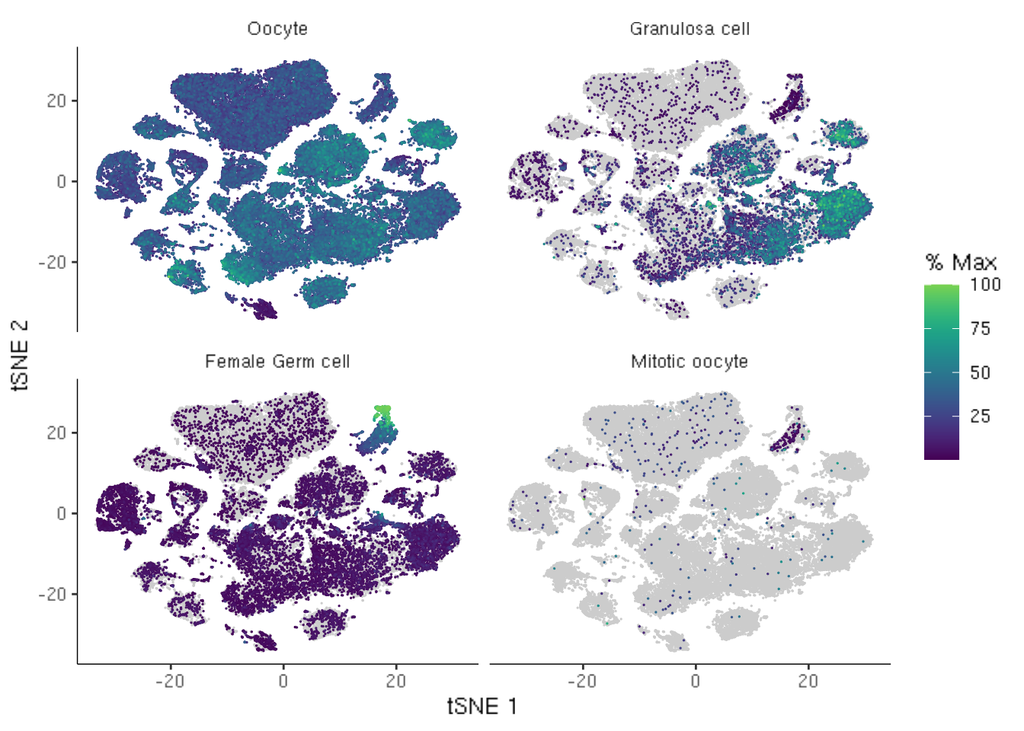

```r
plot_cells(merged.cds, reduction_method = "tSNE",
           genes=chung_davidson_unique %>%
             filter(Group %in% c("Female Germ cell",
                                 "Mitotic oocyte",
                                 "Granulosa cell",
                                 "Oocyte")),
           show_trajectory_graph=FALSE,
           label_cell_groups=FALSE,
           label_leaves=FALSE,
           label_branch_points = FALSE)
```

Male cell markers.

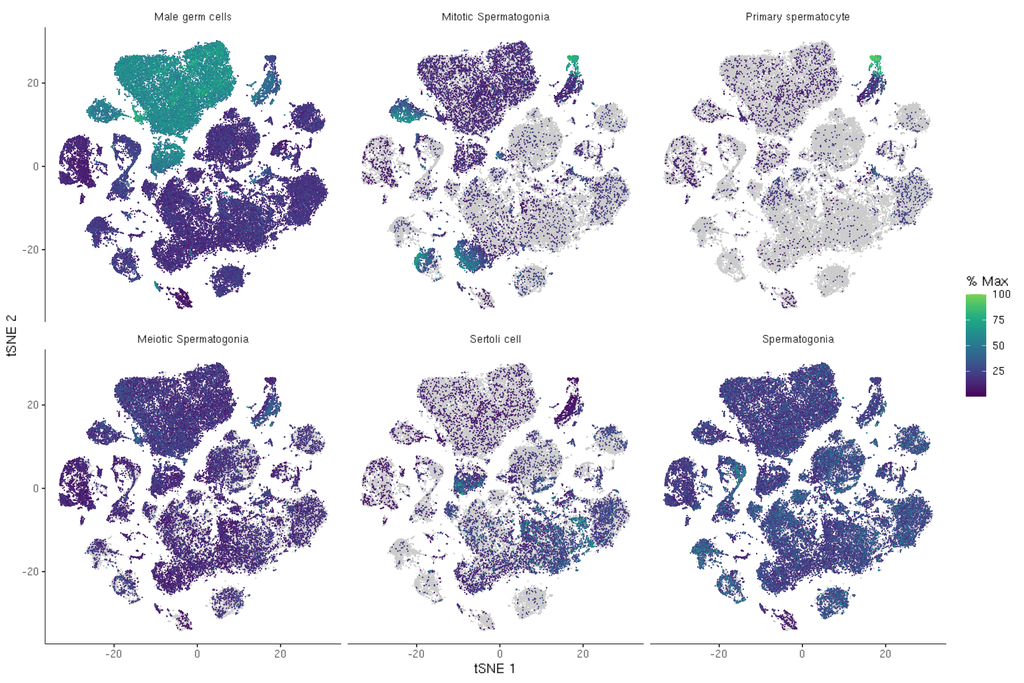

```r
plot_cells(merged.cds, reduction_method = "tSNE",
           genes=chung_davidson_unique %>%
             filter(Group %in% c("Male germ cells",
                                 "Sertoli cell",
                                 "Mitotic Spermatogonia",
                                 "Meiotic Spermatogonia",
                                 "Spermatogonia",
                                 "Primary spermatocyte")),
           show_trajectory_graph=FALSE,
           label_cell_groups=FALSE,
           label_leaves=FALSE,
           label_branch_points = FALSE)
```

## Gene descriptions from Wang et al. and the kPetMar1.pri gtf

Summarized from [Wang et al, 2024](https://www.nature.com/articles/s41467-024-55019-x#Sec16):

The sea lamprey reference genome has over 60% of genes labeled with generic “LOC” numbers, meaning their functions are unknown. To enable proper cell type identification using known retina markers, the researchers re-annotated these genes by finding their human equivalents through the following process: Method:

1. Converted LOC IDs to protein sequences
2. Used BLAST to find matching human proteins
3. Assigned human gene symbols to lamprey genes with human matches (written in UPPERCASE)
4. For genes without human matches, searched other species (written in lowercase)
5. Added suffixes to distinguish genes encoding the same protein

```r
library(readxl)
# https://static-content.springer.com/esm/art%3A10.1038%2Fs41467-024-55019-x/MediaObjects/41467_2024_55019_MOESM3_ESM.xlsx
gene_description =
  read_excel(paste0(data_dir, "/41467_2024_55019_MOESM3_ESM.xlsx"), skip=1) %>%
  dplyr::rename(WangGeneID = "CountMatrix_GeneID",
                Gene = "NCBI_GTF_GENEID",
                description = "NCBI_GTF_ProteinInfo") %>%
  dplyr::select(Gene,WangGeneID,description) %>%
  filter(!is.na(Gene)) %>%
  filter(!WangGeneID %in% c("LOC116945425.1", "S100A1.1")) # loc has two wang ids


gtf = as.data.frame(readGFF("/mnt/research/bioinformaticsCore/shared/Genomes/Petromyzon_marinus/GCF_010993605.1_kPetMar1.pri_genomic.gtf"))

gtf_filt =
  gtf %>%
  filter(gbkey %in% c("mRNA", "misc_RNA", "ncRNA", "tRNA", "rRNA")) %>%
  mutate(product = gsub(", transcript variant.*", "", product)) %>%
  select(gene_id, product) %>%
  distinct() %>%
  dplyr::rename(Gene = "gene_id",
                description = "product") %>%
  mutate(WangGeneID = Gene)


notWang = gtf_filt$Gene[!gtf_filt$Gene %in% gene_description$Gene]

gtf_add =
  gtf_filt %>%
  filter(Gene %in% notWang)

gene_description =
  rbind(gene_description, gtf_add)

write.csv(gene_description, file = paste0(results_dir, "/gene_descritption.csv"), row.names = F)

datatable(gene_description)
```

|  | Gene | WangGeneID | description |
| --- | --- | --- | --- |
| 1 | A2ML1 | A2ML1 | alpha-2-macroglobulin like 1 |
| 2 | AAAS | AAAS | aladin WD repeat nucleoporin, transcript variant X1 |
| 3 | AACS | AACS | model_evidence Supporting evidence includes similarity to: 4 ESTs, 10 Proteins, and 99% coverage of the annotated genomic feature by RNAseq alignments, including 49 samples with support for all annota… |
| 4 | LOC116938545 | aad-a | alpha-aspartyl dipeptidase-like |
| 5 | AADAT | AADAT | aminoadipate aminotransferase |
| 6 | AAGAB | AAGAB | alpha and gamma adaptin binding protein |
| 7 | AAMDC | AAMDC | adipogenesis associated Mth938 domain containing, transcript variant X1 |
| 8 | AAMP | AAMP | angio associated migratory cell protein, transcript variant X2 |
| 9 | AANAT | AANAT | aralkylamine N-acetyltransferase |
| 10 | AAR2 | AAR2 | AAR2 splicing factor, transcript variant X5 |

[output cut: 21957 more lines]

## Compare scatter cluster enriched genes with known markers

### Cluster enriched genes

This table contains the top ~100 cluster enriched genes for each cluster. All of the cluster enriched genes are saved in `results/scatter_cluster_marker_genes.csv`. The markers can help us map a cluster to a cell type.

In this case, genes in each cluster were compared to genes in every other cluster in a pairwise manner, and the p.values and logFCs of those comparisons have been summarized for ease of interpretation.

**Column descriptions**

- `cluster`: The cluster corresponding to the enriched genes.
- `Gene`: The enriched gene
- `p.value`: The combined p-value across all pairwise comparisons.
- `FDR`: The BH-adjusted p-value for each gene.
- `summary.logFC`: This contains the summary effect size, obtained by combining effect sizes from all pairwise comparison into a single value.

```r
scatter_markers = findMarkers(combined.sce,
                              merged.sce$label,
                              test.type="t",
                              block=combined.sce$sample,
                              direction="up",
                              pval.type="some")

saveRDS(scatter_markers, file= paste0(results_dir, "/scatter_markers.Rds"))

scatter_summary = list()

for (i in 1:length(scatter_markers)){

scatter_markers[[i]]$cluster = i
scatter_markers[[i]]$Gene = rownames(scatter_markers[[i]])
scatter_summary[[i]] =
  as.data.frame(scatter_markers[[i]]) %>%
  select(cluster, Gene, p.value, FDR, summary.logFC)

}

scatter_markers_df =
  do.call(rbind, scatter_summary) %>%
  left_join(gene_description, by="Gene") %>%
  filter(FDR < .01)

write.csv(scatter_markers_df, file = paste0(results_dir, "/scatter_cluster_marker_genes.csv"))

scatter_markers_top100 =
  scatter_markers_df %>%
  group_by(cluster) %>%
  slice_min(FDR, n = 100, with_ties=TRUE)

datatable(scatter_markers_top100, filter = "top", rownames = FALSE)
```

| cluster | Gene | p.value | FDR | summary.logFC | WangGeneID | description |
| --- | --- | --- | --- | --- | --- | --- |
| 1 | COL6A2 | 0 | 0 | 3.33275092054236 | COL6A2 | collagen type VI alpha 2 chain, transcript variant X1 |
| 1 | LOC116938842 | 0 | 0 | 2.898349211427449 | COL6A3 | collagen alpha-3(VI) chain-like |
| 1 | LOC116955666 | 0 | 0 | 2.530407483901493 | LOC116955666 | uncharacterized LOC116955666, transcript variant X3 |
| 1 | COL6A1 | 0 | 0 | 4.322101251117065 | COL6A1 | collagen type VI alpha 1 chain |
| 1 | LOC116948593 | 0 | 0 | 5.229058772064612 | COL2A1.2 | collagen alpha-1(II) chain-like |
| 1 | LOC103091741 | 0 | 0 | 3.908177179896214 | BGN.1 | biglycan, transcript variant X1 |
| 1 | SPARC | 0 | 0 | 5.732851647684042 | SPARC | secreted protein acidic and cysteine rich, transcript variant X1 |
| 1 | LOC116952696 | 0 | 0 | 2.307083853409585 | KERA.1 | keratocan-like |
| 1 | LOC116938527 | 0 | 0 | 6.214137595158199 | COL2A1 | collagen alpha-1(II) chain-like |
| 1 | LOC116942816 | 0 | 0 | 3.083295609607938 | LECT2.1 | leukocyte cell-derived chemotaxin-2-like, transcript variant X1 |

[output cut: 2058 more lines]

### Comparison with known markers

We’ll check for the significance of the overlap between the top 100 cluster enriched genes and the supplied known cell-type markers. In the plot below, the rows represent cell types with know marker genes, and the columns represent the cell clusters. The number in each box is the number of genes shared between the top 100 cluster enriched genes for the specified clusters and the specified known cell-type markers. Each box is colored by the significance of the overlap ($-log10(FDR)$). Significant overlaps may signify that the cells in the cluster belong to the specified cell type.

- Overlap p-values are save in `results/scatter_cluster_marker_overlap_pvalues.csv`.
- Overlaps between cluster enriched genes and known marker genes are save in `results/scatter_cluster_marker_gene_overlaps.csv`.

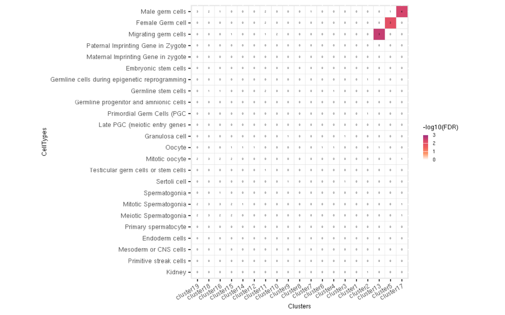

```r
marker_test_genes =
  scatter_markers_top100 %>%
  select(Gene, cluster) %>%
  mutate(cluster = paste0("cluster", cluster))

cluster_ol =  phyperOverlapSets(chung_davidson_cell_type_markers,
                                marker_test_genes, length(merged.sce))

shared_gene_description =
  gene_description %>%
  rename(Gene = "SharedGene")

cluster_ol$intersecting.genes =
  cluster_ol$intersecting.genes %>%
  left_join(shared_gene_description, by="SharedGene")

write.csv(cluster_ol$intersecting.genes, file = paste0(results_dir, "/scatter_cluster_marker_gene_overlaps.csv"), row.names = FALSE)

scores = cluster_ol$pval.scores

scores =
  scores %>%
  rename(Group1 = "CellTypes",
         Group2 = "Clusters") %>%
  group_by(CellTypes) %>%
    mutate(FDR = p.adjust(Pval, "BH"))

write.csv(scores, file = paste0(results_dir, "/scatter_cluster_marker_overlap_pvalues.csv"), row.names = FALSE)

scores$FDR[scores$FDR > .01] = 1

FDR_wide <-
  scores %>%
  mutate(logFDR = -log10(FDR)) %>%
  tidyr::pivot_wider(id_cols = CellTypes,
                     names_from = Clusters,
                     values_from=logFDR)

CellTypes = FDR_wide$CellTypes
FDR_wide$CellTypes = NULL

FDR_wide = as.matrix(FDR_wide)
rownames(FDR_wide) = CellTypes

ord_row <- hclust( dist(FDR_wide), method = "ward.D" )$order
ord_col <- hclust( dist(t(FDR_wide)), method = "ward.D" )$order

scores$CellTypes = factor(scores$CellTypes, levels = rownames(FDR_wide)[ord_row])
scores$Clusters = factor(scores$Clusters, levels = colnames(FDR_wide)[ord_col])

plot1 =
    ggplot(scores,
           aes(Clusters, CellTypes)) +
           geom_tile(aes(fill = -log10(FDR)),
                     color = "light gray") +
        #Creating legend
        guides(fill=guide_colorbar(title = "-log10(FDR)",
                                   barheight = 10,
                                   barwidth = 2,
                                   default.unit = "mm")) +
        #Creating color range
        scale_fill_gradientn(colors=c("white",
                                      "#fd9668",
                                      "#f1605d",
                                      "#de4968",
                                      "#9e2f7f"),
                             guide="colorbar",
                             limits = c(0, ceiling(-log10(min(scores$FDR))))
                             ) +
        #Rotating labels
         theme(axis.text.x = element_text(angle = 30,
                                          hjust = 1,vjust=1),
               ) +
        theme(text = element_text(size = 7),
              axis.text = element_text(size = 7)) +
        geom_text(aes(label = nSharedGenes), size = 1) +
        coord_fixed()

plot1
```

```r
ggsave(plot1, file = paste0(results_dir, "/scatter_cluster_overlap_heatmap.png"))
```

## Gene ontology of top 100 scatter cluster enriched genes

To help annotate cell type clusters, we can check for enriched gene ontology categories among cell-type enriched genes.

**Columns**

- `GOID`: Gene ontology ID
- `GOName`: Gene ontology name
- `nGOTermGenes`: Number of genes assigned to GO term
- `Clusters`: Cluster
- `nClusterEnrichedGenes`: Number of cluster enriched genes
- `nSharedGenes`: Number of shared genes between the GO term and cluster enriched genes
- `Pval`: p-value
- `FDR`: p-value corrected for multiple comparisons

Overlap p-values are save in `results/scatter_cluster_marker_gene_GO_overlap_pvalues.csv`. Overlaps between cluster enriched genes and known marker genes are save in `results/scatter_cluster_marker_gene_GO_overlaps.csv`.

```r
gaf = read.delim("/mnt/research/bioinformaticsCore/shared/Genomes/Petromyzon_marinus/GCF_010993605.1_kPetMar1.pri_gene_ontology.gaf", header=F, comment = "!")

gaf <-
  gaf %>%
  filter(!grepl("NOT", V4)) %>%
  dplyr::select(V3, V5) %>%
  dplyr::rename(GOID = "V5",
                Gene = "V3") %>%
  distinct()

keep_go =
  gaf %>%
  group_by(GOID) %>%
  tally() %>%
  filter(n > 10,
         n < 200) %>%
  pull(GOID)

gaf =
  gaf %>%
  filter(GOID %in% keep_go)

go_names = read.delim("/mnt/research/bioinformaticsCore/shared/Genomes/Petromyzon_marinus/GOs_names.txt", header = F)
colnames(go_names) = c("GOID", "GOName")

go_ol =  phyperOverlapSets(gaf,
                           marker_test_genes, length(merged.cds))

shared_gene_description =
  gene_description %>%
  rename(Gene = "SharedGene")

go_ol$intersecting.genes =
  go_ol$intersecting.genes %>%
  left_join(shared_gene_description, by="SharedGene")

write.csv(go_ol$intersecting.genes, file = paste0(results_dir, "/scatter_cluster_marker_gene_GO_overlaps.csv"), row.names = FALSE)

scores = go_ol$pval.scores

scores =
  scores %>%
  dplyr::rename(GOID = "Group1",
                Clusters = "Group2",
                nGOTermGenes = "nGroup1",
                nClusterEnrichedGenes = "nGroup2") %>%
  group_by(Clusters) %>%
    mutate(FDR = p.adjust(Pval, "BH")) %>%
  select(-Enrichment)

scores =
  left_join(go_names, scores, by="GOID") %>%
  filter(!is.na(nGOTermGenes)) %>%
  filter(Pval < .01)

write.csv(scores, file = paste0(results_dir, "/scatter_cluster_marker_gene_GO_overlap_pvalues.csv"), row.names = FALSE)

datatable(scores, filter = "top", rownames = FALSE)
```

| GOID | GOName | nGOTermGenes | Clusters | nClusterEnrichedGenes | nSharedGenes | Pval | FDR |
| --- | --- | --- | --- | --- | --- | --- | --- |
| GO:0000027 | ribosomal large subunit assembly | 16 | cluster10 | 100 | 2 | 0.002361690308546165 | 0.1670895893296412 |
| GO:0000027 | ribosomal large subunit assembly | 16 | cluster13 | 100 | 2 | 0.002361690308546165 | 0.1670895893296412 |
| GO:0000028 | ribosomal small subunit assembly | 15 | cluster10 | 100 | 7 | 2.043744351559303e-13 | 2.478769934962641e-11 |
| GO:0000028 | ribosomal small subunit assembly | 15 | cluster13 | 100 | 4 | 5.309774988960386e-07 | 6.439998522324811e-05 |
| GO:0000028 | ribosomal small subunit assembly | 15 | cluster18 | 100 | 4 | 5.309774988960386e-07 | 6.439998522324811e-05 |
| GO:0000079 | regulation of cyclin-dependent protein serine/threonine kinase activity | 25 | cluster14 | 100 | 2 | 0.005748986011303322 | 0.1877265047537123 |
| GO:0000079 | regulation of cyclin-dependent protein serine/threonine kinase activity | 25 | cluster15 | 100 | 2 | 0.005748986011303322 | 0.2324232915998343 |
| GO:0000079 | regulation of cyclin-dependent protein serine/threonine kinase activity | 25 | cluster16 | 100 | 2 | 0.005748986011303322 | 0.1952355649438608 |
| GO:0000226 | microtubule cytoskeleton organization | 71 | cluster14 | 100 | 7 | 3.431368993290293e-08 | 9.71077425101153e-06 |
| GO:0000226 | microtubule cytoskeleton organization | 71 | cluster15 | 100 | 5 | 1.813717915325596e-05 | 0.002074390397409099 |

[output cut: 158 more lines]

## Annotations

| cluster | annotation |
| --- | --- |
| 1 | Interstitial stromal cells |
| 2 | Mesonephric stromal cells |
| 3 | Granulosa cells |
| 4 | Leydig cells |
| 5 | Primordial germ cells/oogonia |
| 6 | Endothelial cells |
| 7 | Mesonephric cells |
| 8 | Erythrocytes |
| 9 | Sertoli cells |
| 10 | B lymphocytes |
| 11 | Hemopoietic stem cells |
| 12 | Mesonephric podocytes |
| 13 | Macrophages |
| 14 | Proliferating pre-granulosa cells |
| 15 | Proliferating B cells |
| 16 | Meiotic spermatocyte |
| 17 | Spermatocyte |
| 18 | Mitotic spermatogonia |
| 19 | Migrating male germ cells. |

# Sex cell clusters analysis

Filter for cells in clusters 16, 17, 18, 19, 5

| sex clusters | annotation |
| --- | --- |
| 5 | Primordial germ cells/oogonia |
| 16 | Meiotic spermatocyte |
| 17 | Spermatocyte |
| 18 | Mitotic spermatogonia |
| 19 | Migrating male germ cells |

```r
# Load QC'd data
sample_dirs = list.dirs(data_dir, full.names = TRUE, recursive = FALSE)
sample_names = basename(sample_dirs)

cds_list = list()

for(i in 1:length(sample_dirs)){

  cds_list[[i]] = readRDS(paste0(sample_dirs[i],
                                 "/",
                                 sample_names[i],
                                 "_cds_mito_filter.Rds"))
}

names(cds_list) = sample_names

meta_df = as.data.frame(colData(merged.sce))
meta_df$cells = rownames(meta_df)

all.sex.sce = list()

# cds to sce
for (cds in names(cds_list)){

  raw_counts = counts(cds_list[[cds]])

  all.sce =
    SingleCellExperiment(list(counts=raw_counts),
                         colData=cds_list[[cds]]@colData)

  all.sce@colData$sample = cds

  sex.cells =
   meta_df %>%
   filter(label %in% c(16, 17, 18, 19, 5),
          batch == cds) %>%
   pull(cells)

  all.sex.sce[[cds]] = all.sce[,sex.cells]
}

# https://bioconductor.org/books/3.14/OSCA.multisample/human-pbmcs-10x-genomics.html
# normalization, feature selection, dim reduction
set.seed(1)
all.sex.sce <- lapply(all.sex.sce, logNormCounts)
all.sex.dec <- lapply(all.sex.sce, modelGeneVar)
all.sex.hvgs <- lapply(all.sex.dec, getTopHVGs, prop=0.1)
all.sex.sce <- mapply(FUN=runPCA, x=all.sex.sce, subset_row=all.sex.hvgs)

saveRDS(all.sex.sce, file = paste0(results_dir, "/no.support.sex.sce.Rds"))
```

```r
all.sex.dec <- lapply(all.sex.sce, modelGeneVar)

# integration
# Intersecting the common genes.
universe <- Reduce(intersect, lapply(all.sex.sce, rownames))
all.sex.sce2 <- lapply(all.sex.sce, "[", i=universe,)
all.sex.dec2 <- lapply(all.sex.dec, "[", i=universe,)

# Renormalizing to adjust for differences in depth.
normed.sce <- do.call(multiBatchNorm, all.sex.sce2)

# Identifying a set of HVGs using stats from all batches.
combined.dec <- do.call(combineVar, all.sex.dec2)
combined.hvg <- getTopHVGs(combined.dec, n=5000)
```

```r
set.seed(1)
merged.sex.sce <- do.call(fastMNN, c(normed.sce,
    list(subset.row=combined.hvg, BSPARAM=RandomParam())))

# clustering in corrected space
set.seed(1)
g <- buildSNNGraph(merged.sex.sce, use.dimred="corrected", k = 8)
set.seed(1)
colLabels(merged.sex.sce) <- factor(igraph::cluster_louvain(g)$membership)

# add all cells scatter clusters
all.scatter.clust =
  meta_df %>%
  filter(label %in% c(16, 17, 18, 19, 5)) %>%
  select(cells, label) %>%
  tibble::deframe()

all.scatter.clust <- all.scatter.clust[colnames(merged.sex.sce)]
merged.sex.sce$all.scatter.clust = all.scatter.clust

merged.sex.sce <- runUMAP(merged.sex.sce, dimred="corrected")
merged.sex.sce <- runTSNE(merged.sex.sce, dimred="corrected")

saveRDS(merged.sex.sce, file = paste0(results_dir, "/no.support.merged.sex.sce.Rds"))
```

## Plot new clusters in TSNE space

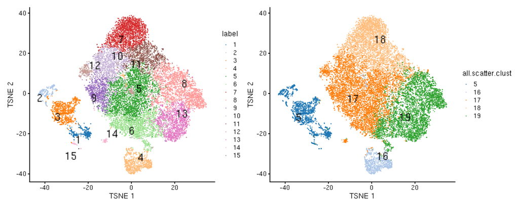

```r
tsne_new = plotTSNE(merged.sex.sce, colour_by="label", text_by="label", text_colour="black", point_size = .05)
tsne_old = plotTSNE(merged.sex.sce, colour_by="all.scatter.clust", text_by="all.scatter.clust", text_colour="black", point_size = .05)
tsne_new + tsne_old
```

### Table of orginal to new cluster assignment

Below is a table showing how many cells from each original sex cell cluster went to each new sex cell cluster.

```r
df <- as.data.frame(merged.sex.sce@colData)

df_count <-
  df %>%
  select(label, all.merged.clusters) %>%
  dplyr::rename(sex.merged.clusters = "label") %>%
  dplyr::count(sex.merged.clusters, all.merged.clusters) %>%
  group_by(all.merged.clusters) %>%
  mutate(total_m1 = sum(n)) %>%
  ungroup() %>%
  group_by(sex.merged.clusters) %>%
  mutate(total_m2 = sum(n)) %>%
  ungroup() %>%
  # Compute the percentage of total in method 1 and method 2
  mutate(
    pct_of_all.clusters = round((n / total_m1) * 100, 2),
    pct_of_sex.clusters = round((n / total_m2) * 100, 2)) %>%
  select(-total_m1, -total_m2)

datatable(df_count, filter = "top", rownames = FALSE)
```

| sex.merged.clusters | all.merged.clusters | n | pct_of_all.clusters | pct_of_sex.clusters |
| --- | --- | --- | --- | --- |
| 1 | 5 | 414 | 20.12 | 97.41 |
| 1 | 17 | 1 | 0.02 | 0.24 |
| 1 | 19 | 10 | 0.2 | 2.35 |
| 2 | 5 | 414 | 20.12 | 100 |
| 3 | 5 | 1161 | 56.41 | 99.15 |
| 3 | 17 | 2 | 0.03 | 0.17 |
| 3 | 18 | 3 | 0.07 | 0.26 |
| 3 | 19 | 5 | 0.1 | 0.43 |
| 4 | 16 | 1097 | 96.06 | 94.98 |
| 4 | 17 | 29 | 0.45 | 2.51 |

[output cut: 39 more lines]

### Sex subclusters mapping to cluster annotations

| sex subclusters | annotation |
| --- | --- |
| 1 | Primordial germ cells/oogonia |
| 2 | Primordial germ cells/oogonia |
| 3 | Primordial germ cells/oogonia |
| 4 | Meiotic spermatocyte |
| 5 | Spermatocyte |
| 6 | Migrating male germ cells + Spermatocyte |
| 7 | Mitotic spermatogonia |
| 8 | Migrating male germ cells + Spermatocyte |
| 9 | Spermatocyte |
| 10 | Spermatocyte + Mitotic spermatogonia |
| 11 | Mitotic spermatogonia |
| 12 | Spermatocyte |
| 13 | Migrating male germ cells |
| 14 | Spermatocyte + Primordial germ cells/oogonia |
| 15 | Primordial germ cells/oogonia |

## Split by sample

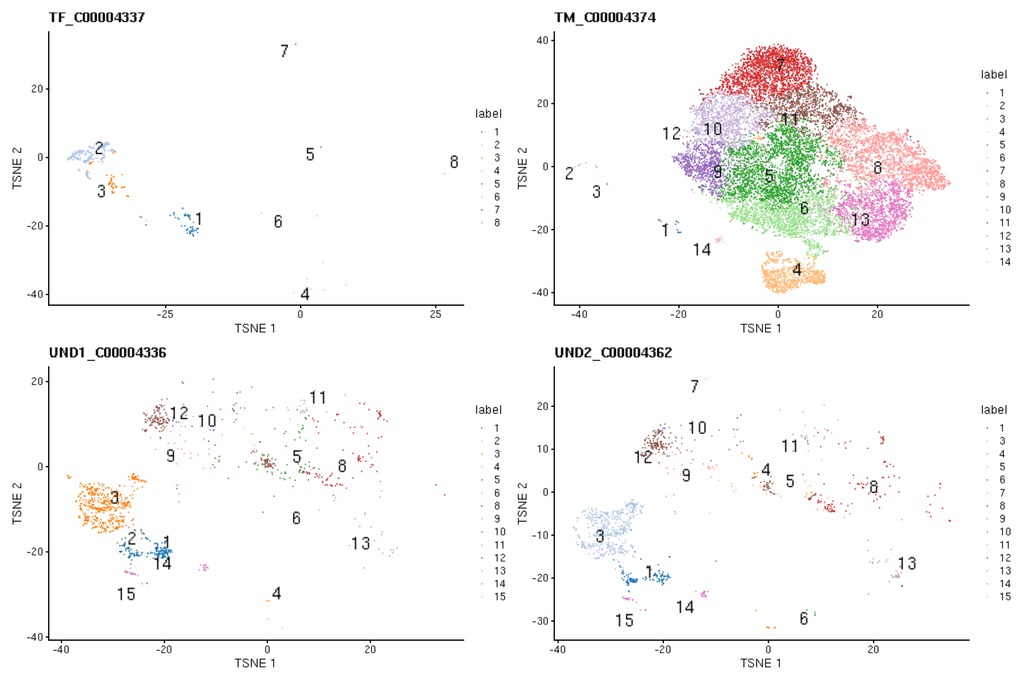

```r
# plot TSNE

p <- lapply(unique(merged.sex.sce$batch), function(f) {
  sce.f = merged.sex.sce[, which(merged.sex.sce$batch == f)]
  plotTSNE(sce.f, colour_by="label", text_by="label", text_colour="black", point_size = .05) + ggtitle(f)
})

wrap_plots(p, ncol = 2)
```

This plot shows the proportion of cells from each sample within each new cluster.

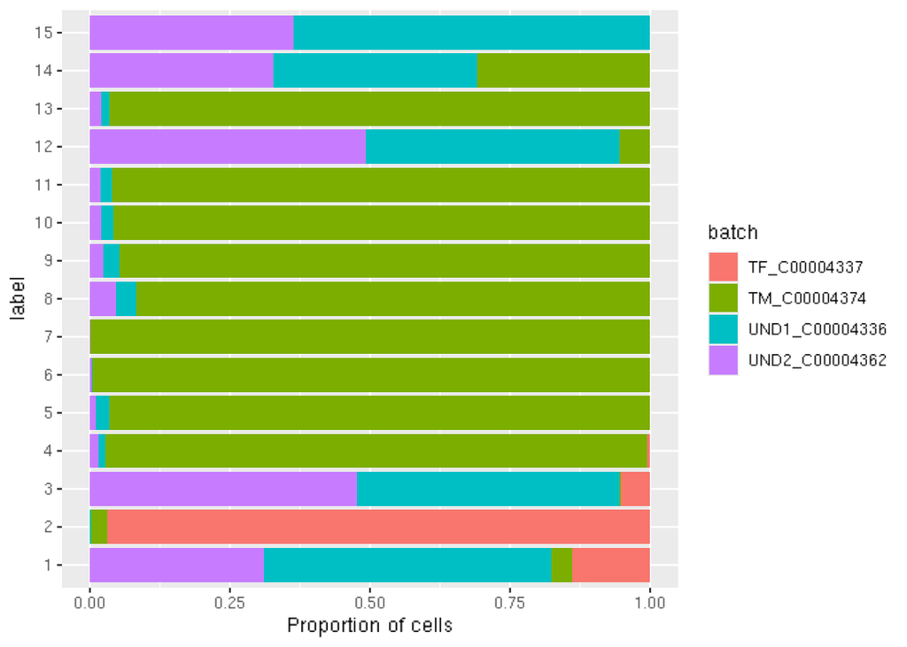

```r
meta_df = as.data.frame(colData(merged.sex.sce))

sample_tally =
  meta_df %>%
  mutate(label = as.factor(label),
         batch = as.factor(batch)) %>%
  group_by(label, batch, .drop = FALSE) %>%
  tally()

ggplot(sample_tally, aes(fill=batch, y=label, x=n)) +
    geom_bar(position="fill", stat="identity") +
    xlab("Proportion of cells")
```

```r
# make cds for plotting with monocle
all.sex.dec <- lapply(all.sex.sce, modelGeneVar)
# integration
# Intersecting the common genes.
universe <- Reduce(intersect, lapply(all.sex.sce, rownames))
all.sex.sce2 <- lapply(all.sex.sce, "[", i=universe,)
all.sex.dec2 <- lapply(all.sex.dec, "[", i=universe,)

all.sex.sce2[["TM_C00004374"]]@colData$cluster="noclust"

combined.sex.sce <- do.call(cbind, all.sex.sce2)
```

```r
merged.sex.cds <- new_cell_data_set(counts(combined.sex.sce),
                                cell_metadata = merged.sex.sce@colData)

reducedDims(merged.sex.cds)$tSNE <- reducedDims(merged.sex.sce)$TSNE
rowData(merged.sex.cds)$gene_short_name = row.names(merged.sex.cds)

saveRDS(merged.sex.cds, file = paste0(results_dir, "/no.support.merged.sex.cds.Rds"))
```

## Plot known markers

Plot for early cell markers.

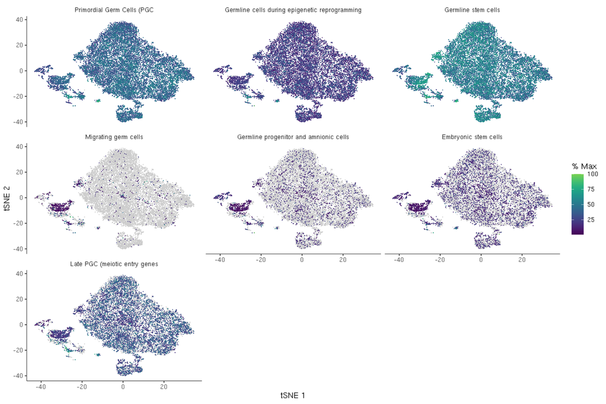

```r
plot_cells(merged.sex.cds, reduction_method = "tSNE",
           genes=chung_davidson_unique %>%
             filter(Group %in% c("Germline cells during epigenetic reprogramming",
                                 "Germline stem cells",
                                 "Embryonic stem cells",
                                 "Germline progenitor and amnionic cells",
                                 "Primordial Germ Cells (PGC",
                                 "Migrating germ cells",
                                 "Late PGC (meiotic entry genes")))
```

Female cell markers

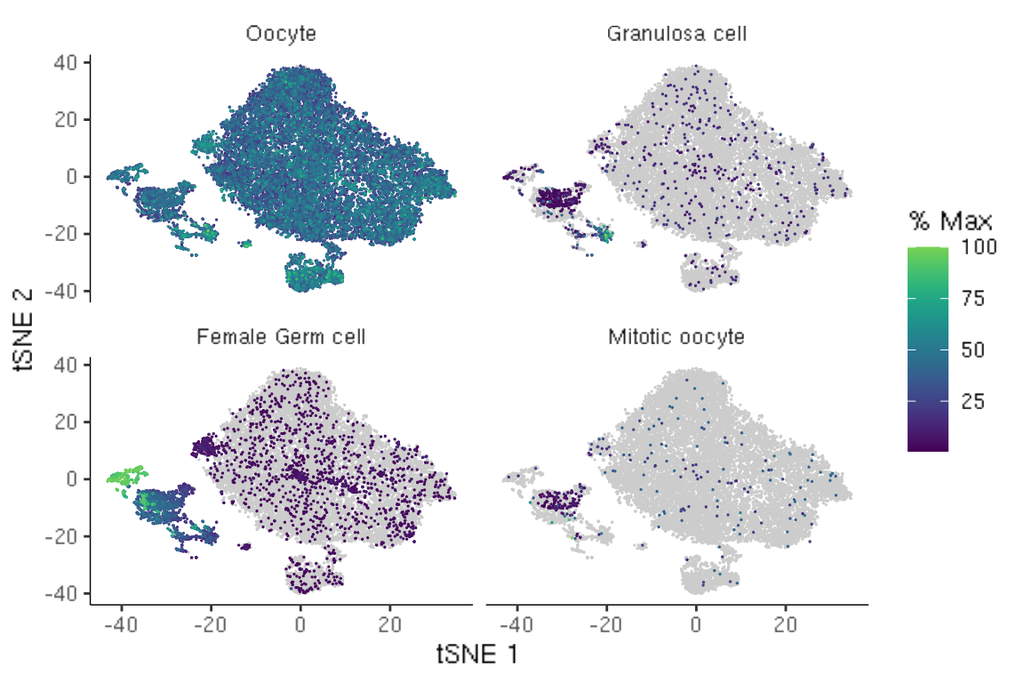

```r
plot_cells(merged.sex.cds, reduction_method = "tSNE",
           genes=chung_davidson_unique %>%
             filter(Group %in% c("Female Germ cell",
                                 "Mitotic oocyte",
                                 "Granulosa cell",
                                 "Oocyte")),
           show_trajectory_graph=FALSE,
           label_cell_groups=FALSE,
           label_leaves=FALSE,
           label_branch_points = FALSE)
```

Male cell markers.

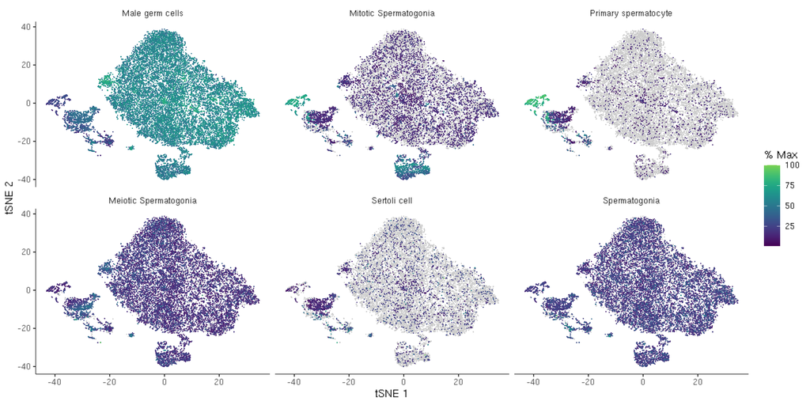

```r
plot_cells(merged.sex.cds, reduction_method = "tSNE",
           genes=chung_davidson_unique %>%
             filter(Group %in% c("Male germ cells",
                                 "Sertoli cell",
                                 "Mitotic Spermatogonia",
                                 "Meiotic Spermatogonia",
                                 "Spermatogonia",
                                 "Primary spermatocyte")),
           show_trajectory_graph=FALSE,
           label_cell_groups=FALSE,
           label_leaves=FALSE,
           label_branch_points = FALSE)
```

## Cluster enriched genes

This table contains the top ~100 cluster enriched genes for each cluster. All of the cluster enriched genes are saved in `sex_scatter_cluster_marker_genes.csv`. The markers can help us map a cluster to a cell type.

In this case, genes in each cluster were compared to genes in every other cluster in a pairwise manner, and the p.values and logFCs of those comparisons have been summarized for ease of interpretation.

**Column descriptions**

- `cluster`: The cluster corresponding to the enriched genes.
- `Gene`: The enriched gene
- `p.value`: The combined p-value across all pairwise comparisons.
- `FDR`: The BH-adjusted p-value for each gene.
- `summary.logFC`: This contains the summary effect size, obtained by combining effect sizes from all pairwise comparison into a single value.
- `WangGeneID`: BLAST equivalent gene name dervived by Wang et al, 2024
- `description`: Gene description

```r
scatter_markers = findMarkers(combined.sex.sce,
                              merged.sex.sce$label,
                              test.type="t",
                              block=combined.sex.sce$sample,
                              direction="up",
                              pval.type="some")

saveRDS(scatter_markers, file= paste0(results_dir, "/no.support_sex_scatter_markers.Rds"))
```

```r
scatter_markers = readRDS(paste0(results_dir, "/no.support_sex_scatter_markers.Rds"))

scatter_summary = list()

for (i in 1:length(scatter_markers)){

scatter_markers[[i]]$cluster = i
scatter_markers[[i]]$Gene = rownames(scatter_markers[[i]])
scatter_summary[[i]] =
  as.data.frame(scatter_markers[[i]]) %>%
  select(cluster, Gene, p.value, FDR, summary.logFC)

}

scatter_markers_df =
  do.call(rbind, scatter_summary) %>%
  left_join(gene_description, by="Gene") %>%
  mutate(cluster = paste0("cluster_",cluster)) %>%
  filter(FDR < .01)

write.csv(scatter_markers_df, file = paste0(results_dir, "/no.support_sex_scatter_cluster_marker_genes.csv"))

scatter_markers_top100 =
  scatter_markers_df %>%
  group_by(cluster) %>%
  slice_min(FDR, n = 100, with_ties=TRUE) %>%
  mutate(p.value = formatC(signif(p.value, digits = 3)),
         FDR = formatC(signif(FDR, digits = 3)),
         summary.logFC = round(summary.logFC, digits = 3))

datatable(scatter_markers_top100, filter = "top", rownames = FALSE)
```

| cluster | Gene | p.value | FDR | summary.logFC | WangGeneID | description |
| --- | --- | --- | --- | --- | --- | --- |
| cluster_1 | LOC116947083 | 2.16e-79 | 4.75e-75 | 3.2 | S100A1-3 | protein S100-A1-like |
| cluster_1 | LOC116947145 | 1.49e-69 | 1.64e-65 | 2.792 | S100A1-12 | protein S100-A1-like, transcript variant X1 |
| cluster_1 | LOC116947140 | 4.56e-67 | 3.34e-63 | 2.983 | S100A1-7 | protein S100-A1-like |
| cluster_1 | LOC116945224 | 1.39e-66 | 7.63e-63 | 3.534 | EEF1A1 | elongation factor 1-alpha 1-like |
| cluster_1 | LOC116956104 | 9.07e-64 | 3.98e-60 | 2.674 | CUZD1.7 | CUB and zona pellucida-like domain-containing protein 1 |
| cluster_1 | LOC116950895 | 1.22e-62 | 4.47e-59 | 3.492 | LOC116950895 | uncharacterized LOC116950895 |
| cluster_1 | LOC116947141 | 1.05e-61 | 3.3e-58 | 2.967 | S100A1-8 | protein S100-A1-like |
| cluster_1 | LOC116947087 | 2e-61 | 5.49e-58 | 3.57 | S100A1-6 | protein S100-A1-like |
| cluster_1 | LOC116947142 | 3.72e-58 | 9.08e-55 | 2.746 | S100A1-9 | protein S100-A1-like |
| cluster_1 | LOC116956112 | 6.37e-57 | 1.4e-53 | 2.839 | CUZD1.15 | CUB and zona pellucida-like domain-containing protein 1 |

[output cut: 1356 more lines]

## Comparison with known markers

We’ll check for the significance of the overlap between the top 100 cluster enriched genes and the supplied known cell-type markers. In the plot below, the rows represent cell types with know marker genes, and the columns represent the cell clusters. The number in each box is the number of genes shared between the top 100 cluster enriched genes for the specified clusters and the specified known cell-type markers. Each box is colored by the significance of the overlap ($-log10(FDR)$). Significant overlaps may signify that the cells in the cluster belong to the specified cell type.

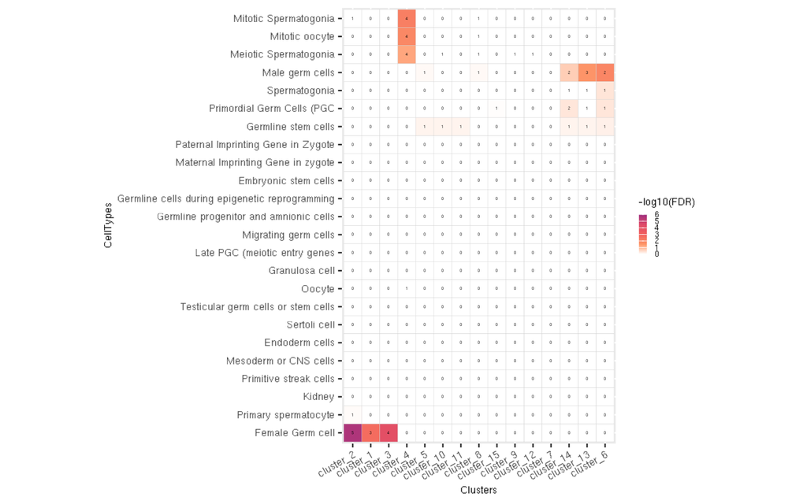

```r
marker_test_genes =
  scatter_markers_top100 %>%
  select(Gene, cluster)

cluster_ol =  phyperOverlapSets(chung_davidson_cell_type_markers,
                                marker_test_genes, length(merged.sex.sce))

shared_gene_description =
  gene_description %>%
  dplyr::rename(SharedGene = "Gene")

cluster_ol$intersecting.genes =
  cluster_ol$intersecting.genes %>%
  left_join(shared_gene_description, by="SharedGene")

write.csv(cluster_ol$intersecting.genes, file = paste0(results_dir, "/no.support_sex_scatter_cluster_marker_gene_overlaps.csv"), row.names = FALSE)

scores = cluster_ol$pval.scores

scores =
  scores %>%
  dplyr::rename(CellTypes = "Group1",
         Clusters = "Group2") %>%
  group_by(CellTypes) %>%
    mutate(FDR = p.adjust(Pval, "BH"))

#scores$FDR[scores$FDR > .01] = 1

FDR_wide <-
  scores %>%
  mutate(logFDR = -log10(FDR)) %>%
  tidyr::pivot_wider(id_cols = CellTypes,
                    names_from = Clusters,
                    values_from=logFDR)

CellTypes = FDR_wide$CellTypes
FDR_wide$CellTypes = NULL

FDR_wide = as.matrix(FDR_wide)
rownames(FDR_wide) = CellTypes

ord_row <- hclust( dist(FDR_wide), method = "ward.D" )$order
ord_col <- hclust( dist(t(FDR_wide)), method = "ward.D" )$order

scores$CellTypes = factor(scores$CellTypes, levels = rownames(FDR_wide)[ord_row])
scores$Clusters = factor(scores$Clusters, levels = colnames(FDR_wide)[ord_col])

plot1 =
    ggplot(scores,
           aes(Clusters, CellTypes)) +
           geom_tile(aes(fill = -log10(FDR)),
                     color = "light gray") +
        #Creating legend
        guides(fill=guide_colorbar(title = "-log10(FDR)",
                                   barheight = 10,
                                   barwidth = 2,
                                   default.unit = "mm")) +
        #Creating color range
        scale_fill_gradientn(colors=c("white",
                                      "#fd9668",
                                      "#f1605d",
                                      "#de4968",
                                      "#9e2f7f"),
                             guide="colorbar",
                             limits = c(0, ceiling(-log10(min(scores$FDR))))
                             ) +
        #Rotating labels
         theme(axis.text.x = element_text(angle = 30,
                                          hjust = 1,vjust=1),
               ) +
        theme(text = element_text(size = 7),
              axis.text = element_text(size = 7)) +
        geom_text(aes(label = nSharedGenes), size = 1) +
        coord_fixed()

plot1
```

```r
ggsave(plot1, file = paste0(results_dir, "/no.support_sex_scatter_cluster_overlap_heatmap.png"))
```

## Gene ontology of top 100 scatter cluster enriched genes

To help annotate cell type clusters, we can check for enriched gene ontology categories among cell-type enriched genes.

**Columns**

- `GOID`: Gene ontology ID
- `GOName`: Gene ontology name
- `nGOTermGenes`: Number of genes assigned to GO term
- `Clusters`: Cluster
- `nClusterEnrichedGenes`: Number of cluster enriched genes
- `nSharedGenes`: Number of shared genes between the GO term and cluster enriched genes
- `Pval`: p-value
- `FDR`: p-value corrected for multiple comparisons

```r
gaf = read.delim("/mnt/research/bioinformaticsCore/shared/Genomes/Petromyzon_marinus/GCF_010993605.1_kPetMar1.pri_gene_ontology.gaf", header=F, comment = "!")

gaf <-
  gaf %>%
  filter(!grepl("NOT", V4)) %>%
  dplyr::select(V3, V5) %>%
  dplyr::rename(GOID = "V5",
                Gene = "V3") %>%
  distinct()

keep_go =
  gaf %>%
  group_by(GOID) %>%
  tally() %>%
  filter(n > 10,
         n < 200) %>%
  pull(GOID)

gaf =
  gaf %>%
  filter(GOID %in% keep_go)

go_names = read.delim("/mnt/research/bioinformaticsCore/shared/Genomes/Petromyzon_marinus/GOs_names.txt", header = F)
colnames(go_names) = c("GOID", "GOName")

go_ol =  phyperOverlapSets(gaf,
                           marker_test_genes, length(merged.sex.sce))

shared_gene_description =
  gene_description %>%
  dplyr::rename(SharedGene = "Gene")

go_ol$intersecting.genes =
  go_ol$intersecting.genes %>%
  left_join(shared_gene_description, by="SharedGene")

write.csv(go_ol$intersecting.genes, file = paste0(results_dir, "/no.support_sex_scatter_cluster_marker_gene_GO_overlaps.csv"), row.names = FALSE)

scores = go_ol$pval.scores

scores =
  scores %>%
  dplyr::rename(GOID = "Group1",
                Clusters = "Group2",
                nGOTermGenes = "nGroup1",
                nClusterEnrichedGenes = "nGroup2") %>%
  group_by(Clusters) %>%
    mutate(FDR = p.adjust(Pval, "BH")) %>%
  select(-Enrichment)

scores =
  left_join(go_names, scores, by="GOID") %>%
  filter(!is.na(nGOTermGenes)) %>%
  filter(nSharedGenes > 0)

write.csv(scores, file = paste0(results_dir, "/no.support_sex_scatter_cluster_marker_gene_GO_pvals.csv"), row.names = FALSE)

datatable(scores, filter = "top", rownames = FALSE)
```

| GOID | GOName | nGOTermGenes | Clusters | nClusterEnrichedGenes | nSharedGenes | Pval | FDR |
| --- | --- | --- | --- | --- | --- | --- | --- |
| GO:0000027 | ribosomal large subunit assembly | 16 | cluster_10 | 100 | 2 | 0.03960594588450352 | 1 |
| GO:0000027 | ribosomal large subunit assembly | 16 | cluster_11 | 100 | 4 | 0.0002279454850028617 | 0.0241907145959287 |
| GO:0000027 | ribosomal large subunit assembly | 16 | cluster_12 | 100 | 2 | 0.03960594588450352 | 1 |
| GO:0000027 | ribosomal large subunit assembly | 16 | cluster_13 | 100 | 1 | 0.276557447285397 | 1 |
| GO:0000027 | ribosomal large subunit assembly | 16 | cluster_14 | 100 | 1 | 0.276557447285397 | 1 |
| GO:0000027 | ribosomal large subunit assembly | 16 | cluster_5 | 100 | 2 | 0.03960594588450352 | 1 |
| GO:0000027 | ribosomal large subunit assembly | 16 | cluster_7 | 101 | 3 | 0.003700539804878357 | 0.4488226134773893 |
| GO:0000027 | ribosomal large subunit assembly | 16 | cluster_8 | 100 | 2 | 0.03960594588450352 | 1 |
| GO:0000027 | ribosomal large subunit assembly | 16 | cluster_9 | 100 | 2 | 0.03960594588450352 | 1 |
| GO:0000028 | ribosomal small subunit assembly | 15 | cluster_10 | 100 | 1 | 0.2617479784478409 | 1 |

[output cut: 508 more lines]

# Sex cell developement trajectory analysis

## Trajectory plotted in TSNE space

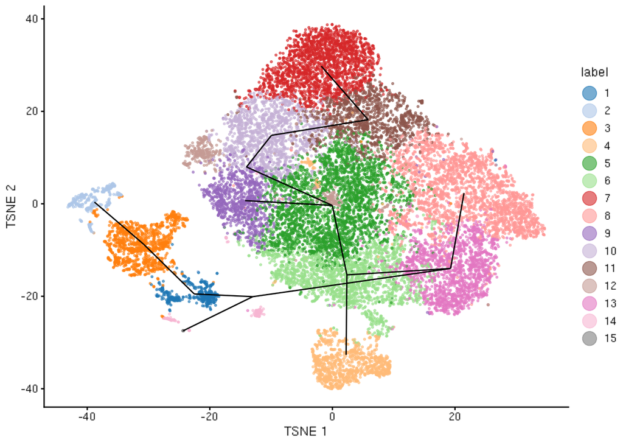

```r
set.seed(1)
by.cluster <- aggregateAcrossCells(merged.sex.sce,
                                   ids=colLabels(merged.sex.sce), use.assay.type = "reconstructed")

centroids <- reducedDim(by.cluster, "corrected")

mst <- createClusterMST(centroids, clusters=NULL)

line.data <- reportEdges(by.cluster, mst=mst, clusters=NULL, use.dimred="TSNE")

plotTSNE(merged.sex.sce, colour_by="label", point_size = .5) +
    geom_line(data=line.data, mapping=aes(x=TSNE1, y=TSNE2, group=edge)) +
  guides(color = guide_legend(override.aes = list(size=5)))
```

## Trajectory plotted in batch corrected gene expression space

It’s hard to interpret this in TSNE space, so we’ll plot in batch corrected expression space instead because the clusters and trajectory analysis were actually calculated in batch corrected expression space.

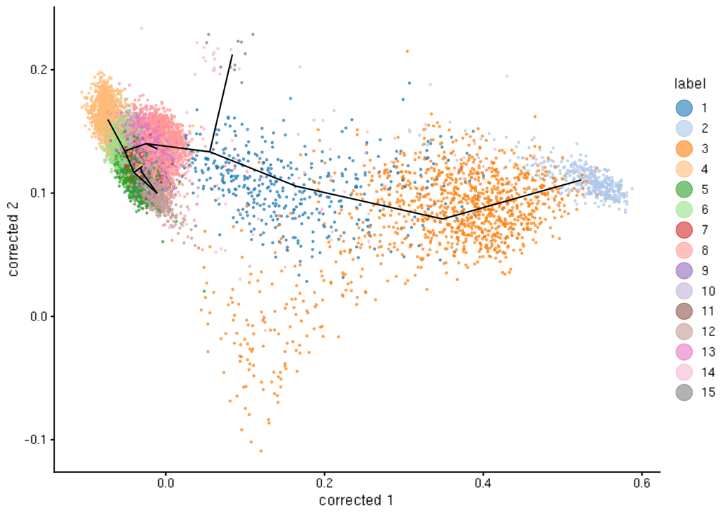

```r
line.data_corrected <- reportEdges(by.cluster, mst=mst, clusters=NULL, use.dimred="corrected")

plotReducedDim(merged.sex.sce, colour_by="label", dimred = "corrected", point_size = .4) +
    geom_line(data=line.data_corrected, mapping=aes(x=dim1, y=dim2, group=edge)) + guides(color = guide_legend(override.aes = list(size=5)))
```

```r
set.seed(1)
pseudo <- quickPseudotime(merged.sex.sce, use.dimred="corrected", outgroup=FALSE, start = 15)
saveRDS(pseudo, file=paste0(results_dir, "/no.support_sex_pseudo.Rds"))
```

## Trajectory plotted with each cluster as a node

Simplify even further.

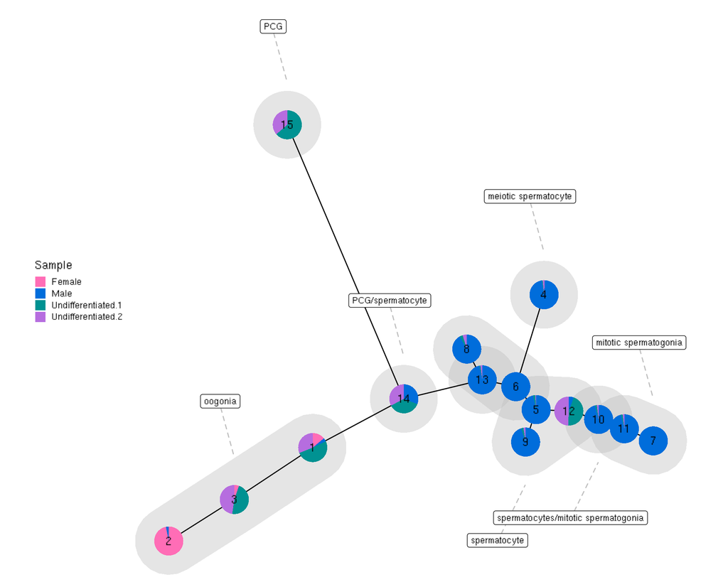

```r
pseudo = readRDS(paste0(results_dir, "/no.support_sex_pseudo.Rds"))

library(ggforce)
library(ggraph)
library(tidygraph)
library(scatterpie)
library(ggrepel)

gr <- as_tbl_graph(pseudo$mst)

node_meta =
  sample_tally %>%
  mutate(batch = case_when(
    batch == "TF_C00004337" ~ "Female",
    batch == "TM_C00004374" ~ "Male",
    batch == "UND1_C00004336" ~ "Undifferentiated.1",
    batch == "UND2_C00004362" ~ "Undifferentiated.2"
  )) %>%
  tidyr::pivot_wider(names_from = batch, values_from = n) %>%
  mutate(totalCells = sum(Female,
                          Male,
                          Undifferentiated.1,
                          Undifferentiated.2,
                          na.rm = TRUE)) %>%
  dplyr::rename(name = "label")

group_vec =
  c("oogonia",
    "oogonia",
    "oogonia",
    "meiotic spermatocyte",
    "spermatocyte",
    "migrating male GC/spermatocyte",
    "mitotic spermatogonia",
    "migrating male GC/spermatocyte",
    "spermatocyte",
    "spermatocytes/mitotic spermatogonia",
    "mitotic spermatogonia",
    "spermatocyte",
    "migrating male GC",
    "PCG/spermatocyte",
    "PCG"
    )

node_meta$CellType = group_vec

gr =
  gr %>%
  activate(nodes) %>%
  left_join(node_meta) %>%
  arrange(desc(totalCells))


layout_data <- create_layout(gr, layout = 'stress')

hull_data <- layout_data %>%
  group_by(CellType) %>%
  slice(chull(x, y))

lab_data1 =
  hull_data %>%
  filter(name %in% c("15", "4", "14", "3", "7")) %>%
  mutate(y = y+.15)

lab_data2 =
  hull_data %>%
  filter(name %in% c("10", "9")) %>%
  mutate(y = y-.15)

gr_plot =
  ggraph(gr, "stress") +
    # Hulls mapped to CellType, but all gray + no legend
    geom_shape(
      data = hull_data,
      aes(x, y,
          fill = CellType,
          fill = after_scale("gray"),
          group = CellType),
      expand = 0.06,
      radius = 0.06,
      show.legend = FALSE,
      alpha = .4
    ) +
    geom_edge_link() +
    # Scatter pies with manual color scale + legend
    geom_label_repel(
      data = lab_data1,
      aes(x, y, label = CellType),
      nudge_y = 0.2,
      nudge_x = -0.05,
      color = "black",
      size = 3,
      force = 5,
      segment.color = "gray",
      segment.linetype = "dashed"
    ) +
    geom_label_repel(
      data = lab_data2,
      aes(x, y, label = CellType),
      nudge_y = -0.2,
      nudge_x = -0.1,
      color = "black",
      size = 3,
      force = 5,
      segment.color = "gray",
      segment.linetype = "dashed"
    ) +
    geom_scatterpie(
      aes(x, y),
      cols = c("Female", "Male", "Undifferentiated.1", "Undifferentiated.2"),
      data = layout_data,
      colour = NA,
      pie_scale = 1.5
    ) +
    scale_fill_manual(
      name = "Sample",
      values = c(
        "Female" = "#FF6DB6",
        "Male" = "#006ddb",
        "Undifferentiated.1" = "#009292",
        "Undifferentiated.2" = "#b66ddf"
      )
    ) +
    guides(fill = guide_legend(keywidth = .8,
                               keyheight =.8)) +
    geom_node_text(aes(label = name), color = "black") +
    theme_void() +
    theme(
      legend.position = "left",
      legend.justification = "center",  # left-align content inside legend box
      legend.box.just = "center"           # align legend box in layout
    )
gr_plot + coord_fixed()
```

```r
# gr_plot =
#   ggraph(gr, "stress") +
#     # Hulls mapped to CellType, but all gray + no legend
#     geom_shape(
#       data = hull_data,
#       aes(x, y,
#           fill = CellType,
#           fill = after_scale("gray"),
#           group = CellType),
#       expand = 0.06,
#       radius = 0.06,
#       show.legend = FALSE,
#       alpha = .4
#     ) +
#     geom_edge_link() +
#     # Scatter pies with manual color scale + legend
#     geom_scatterpie(
#       aes(x, y),
#       cols = c("Female", "Male", "Undifferentiated.1", "Undifferentiated.2"),
#       data = layout_data,
#       colour = NA,
#       pie_scale = 1.5
#     ) +
#     scale_fill_manual(
#       name = "Sample",
#       values = c(
#         "Female" = "#FF6DB6",
#         "Male" = "#006ddb",
#         "Undifferentiated.1" = "#009292",
#         "Undifferentiated.2" = "#b66ddf"
#       )
#     ) +
#     guides(fill = guide_legend(keywidth = 0.6,
#                                keyheight = 0.6)) +
#     geom_node_text(aes(label = name), color = "black", size = 3) +
#     theme_void()
```

## Plot pseudotime

### In tSNE space

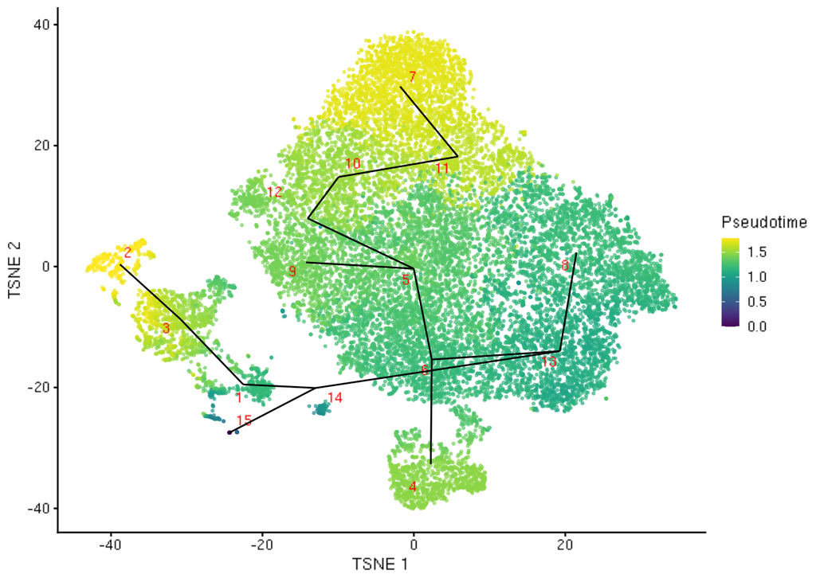

```r
common.pseudo <- averagePseudotime(pseudo$ordering)
merged.sex.sce$Pseudotime <- common.pseudo

pseudo_plot =
  plotTSNE(merged.sex.sce, colour_by="Pseudotime",
        text_by="label", text_colour="red",  point_size = .5, text_size = 3) +
    geom_line(data=line.data, mapping=aes(x=TSNE1, y=TSNE2, group=edge))

pseudo_plot
```

### In batch corrected gene expression space

It’s hard to interpret this in TSNE space, so we’ll plot in batch corrected expression space instead because the clusters and trajectory analysis were actually calculated in batch corrected expression space.

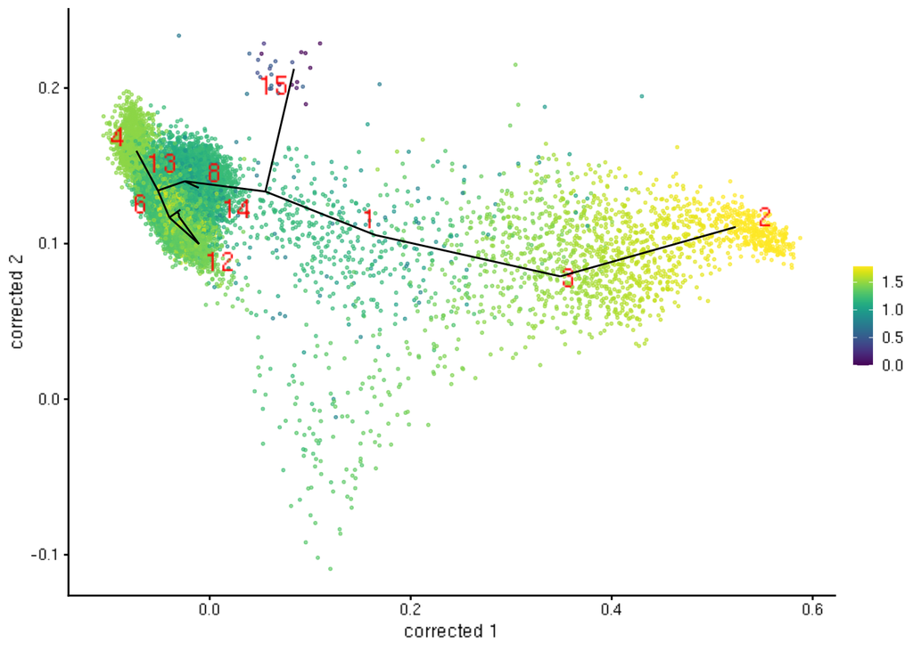

```r
plotTSNE(merged.sex.sce, dimred = "corrected", colour_by=I(common.pseudo),
        text_by="label", text_colour="red",  point_size = .5) +
     geom_line(data=line.data_corrected, mapping=aes(x=dim1, y=dim2, group=edge))
```

## Genes changing with pseudotime along each path

Top ~100 genes by FDR changing with pseudotime along each path. All of the significant genes are saved in `/no.support_sex_pseudotime_de_genes.csv`

**Column descriptions**

- `Path`: The leaf node of the path along which the genes are changing
- `SYMBOL`: The pseudotime-associated gene
- `WangGeneID`: BLAST equivalent gene name derived by Wang et al, 2024
- `description`: Gene description
- `logFC`: estimated log-fold change of expression along the path
- `p.value`: p-value for each gene.
- `FDR`: The BH-adjusted p-value for each gene.

```r
pseudo_mat = pathStat(pseudo$ordering)
test_pseudo <- TSCAN::testPseudotime(combined.sex.sce,
                              pseudotime=pseudo_mat)

test_pseudo_filt = list()

for (i in 1:length(test_pseudo)){

  test_pseudo[[i]]$SYMBOL <- rownames(combined.sex.sce)
  test_pseudo[[i]]$Path <- names(test_pseudo)[i]

  test_pseudo_filt[[i]] =
    as.data.frame(test_pseudo[[i]]) %>%
    filter(FDR < .01) %>%
    arrange(desc(abs(logFC)))

}

test_pseudo_filt_df = do.call(rbind, test_pseudo_filt)

symbol_description =
  gene_description %>%
  dplyr::rename(SYMBOL = "Gene")

test_pseudo_filt_df =
  do.call(rbind, test_pseudo_filt) %>%
  left_join(symbol_description, by = "SYMBOL")

test_pseudo_filt_df = test_pseudo_filt_df[, c("Path", "SYMBOL", "WangGeneID", "description", "logFC", "p.value", "FDR")]

write.csv(test_pseudo_filt_df, file = paste0(results_dir, "/no.support_sex_pseudotime_de_genes.csv"))

test_pseudo100 =
  test_pseudo_filt_df %>%
  mutate(Path = case_when(
    logFC > 0 ~ paste0(Path, ".Upregulated"),
    logFC < 0 ~  paste0(Path, ".Downregulated"))
    ) %>%
  group_by(Path) %>%
  slice_min(order_by = FDR, n=100) %>%
  mutate(logFC = round(logFC, digits = 2),
         p.value = formatC(signif(p.value, digits = 2)),
         FDR = formatC(signif(FDR, digits = 2)))

test_pseudo =
  test_pseudo_filt_df %>%
  mutate(Path = case_when(
    logFC > 0 ~ paste0(Path, ".Upregulated"),
    logFC < 0 ~  paste0(Path, ".Downregulated"))
    ) %>%
  group_by(Path) %>%
  mutate(logFC = round(logFC, digits = 2),
         p.value = formatC(signif(p.value, digits = 2)),
         FDR = formatC(signif(FDR, digits = 2)))

datatable(test_pseudo100, filter = "top", rownames = FALSE)
```

| Path | SYMBOL | WangGeneID | description | logFC | p.value | FDR |
| --- | --- | --- | --- | --- | --- | --- |
| 2.Downregulated | unassigned_gene_5 | unassigned_gene_5 | l-rRNA | -4.6 | 0 | 0 |
| 2.Downregulated | LOC116937934 | LOC116937934 | uncharacterized LOC116937934 | -3.84 | 0 | 0 |
| 2.Downregulated | COX3 | COX3 | cytochrome c oxidase subunit III | -3.81 | 0 | 0 |
| 2.Downregulated | COX1 | COX1 | cytochrome c oxidase subunit I | -3.77 | 0 | 0 |
| 2.Downregulated | CYTB | CYTB | cytochrome b | -3.71 | 0 | 0 |
| 2.Downregulated | ATP6 | ATP6 | ATP synthase F0 subunit 6 | -3.27 | 0 | 0 |
| 2.Downregulated | LOC116946621 | LOC116946621 | elongation factor 1-alpha, somatic form, transcript variant X2 | -2.97 | 0 | 0 |
| 2.Downregulated | PABPC1 | PABPC1 | poly(A) binding protein cytoplasmic 1, transcript variant X2 | -2.09 | 0 | 0 |
| 2.Downregulated | LOC116952102 | CNDP2-1 | cytosolic non-specific dipeptidase-like, transcript variant X3 | -2.08 | 0 | 0 |
| 2.Downregulated | PHF12 | PHF12 | PHD finger protein 12, transcript variant X1 | -1.76 | 0 | 0 |

[output cut: 1120 more lines]

## Gene ontology enrichment, top ~100 genes

**Columns**

- `GOID`: Gene ontology ID
- `GOName`: Gene ontology name
- `nGOTermGenes`: Number of genes assigned to GO term
- `Path`: Trajectory path, upregulated or downregulated genes
- `nPathDEGenes`: Number of pseudotime-associated genes
- `nSharedGenes`: Number of shared genes between the GO term and pseudotime-associated genes
- `Pval`: p-value of the pseudotime association
- `FDR`: p-value corrected for multiple comparisons

```r
test_pseudo100_genes =
  test_pseudo100 %>%
  select(SYMBOL, Path)

go_ol =  phyperOverlapSets(gaf,
                           test_pseudo100_genes, length(merged.sex.sce))

shared_gene_description =
  gene_description %>%
  dplyr::rename(SharedGene = "Gene")

go_int =
  go_ol$intersecting.genes %>%
  left_join(shared_gene_description, by="SharedGene") %>%
  filter(!SharedGene == "none") %>%
  dplyr::rename(GOID = "Group1",
                Path = "Group2") %>%
  left_join(go_names, by="GOID") %>%
  relocate(GOName, .after = GOID)

write.csv(go_int, file = paste0(results_dir, "/no.support_sex_pseudotime_de_top100_GO_overlaps.csv"), row.names = FALSE)

scores = go_ol$pval.scores

scores =
  scores %>%
  dplyr::rename(GOID = "Group1",
                Path = "Group2",
                nGOTermGenes = "nGroup1",
                nPathDEGenes = "nGroup2") %>%
    mutate(FDR = p.adjust(Pval, "BH")) %>%
  select(-Enrichment)

scores =
  left_join(go_names, scores, by="GOID") %>%
  filter(!is.na(nGOTermGenes)) %>%
  filter(FDR < .01)

write.csv(scores, file = paste0(results_dir, "/no.support_sex_pseudotime_de_top100_GO_pvals.csv"), row.names = FALSE)


datatable(scores, filter = "top", rownames = FALSE)
```

| GOID | GOName | nGOTermGenes | Path | nPathDEGenes | nSharedGenes | Pval | FDR |
| --- | --- | --- | --- | --- | --- | --- | --- |
| GO:0000028 | ribosomal small subunit assembly | 15 | 2.Downregulated | 100 | 5 | 7.416303475075153e-06 | 0.001399209255630845 |
| GO:0000028 | ribosomal small subunit assembly | 15 | 4.Upregulated | 100 | 5 | 7.416303475075153e-06 | 0.001399209255630845 |
| GO:0000028 | ribosomal small subunit assembly | 15 | 7.Upregulated | 219 | 7 | 1.340601481862293e-06 | 0.000264690850721183 |
| GO:0000028 | ribosomal small subunit assembly | 15 | 8.Upregulated | 100 | 6 | 2.382230599147204e-07 | 5.056284446689941e-05 |
| GO:0000028 | ribosomal small subunit assembly | 15 | 9.Upregulated | 100 | 6 | 2.382230599147204e-07 | 5.056284446689941e-05 |
| GO:0002181 | cytoplasmic translation | 24 | 2.Downregulated | 100 | 12 | 4.636799516926004e-15 | 1.157836114667699e-12 |
| GO:0002181 | cytoplasmic translation | 24 | 4.Upregulated | 100 | 12 | 4.636799516926004e-15 | 1.157836114667699e-12 |
| GO:0002181 | cytoplasmic translation | 24 | 7.Upregulated | 219 | 13 | 2.50424743383368e-12 | 6.074588775213697e-10 |
| GO:0002181 | cytoplasmic translation | 24 | 8.Upregulated | 100 | 14 | 1.071637373548091e-18 | 3.36970418571233e-16 |
| GO:0002181 | cytoplasmic translation | 24 | 9.Upregulated | 100 | 13 | 7.683547190850833e-17 | 2.038541114072612e-14 |

[output cut: 9 more lines]

## Genes differentially expressed immediately following the branch point in cluster 14

A more advanced analysis involves looking for differences in expression between paths of a branched trajectory. This is most interesting for cells close to the branch point between two or more paths where the differential expression analysis may highlight genes responsible for the branching event. The general strategy here is to fit one trend to the unique part of each path immediately following the branch point, followed by a comparison of the fits between paths.

These plots show pseudotime in cells in cluster 14 along paths 2 and 8 which separate male and female trajectories.

### In TSNE space

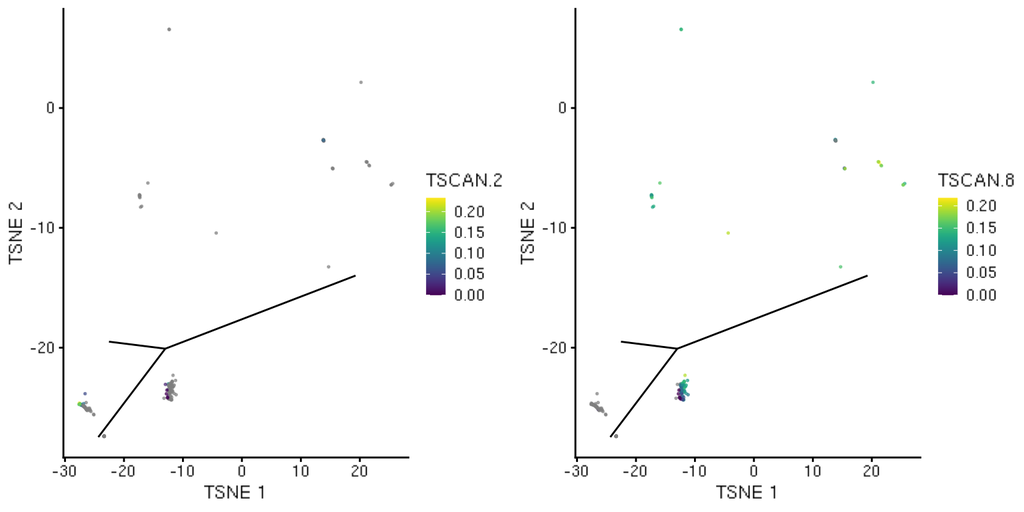

```r
set.seed(1)
pseudo14 <- quickPseudotime(merged.sex.sce, use.dimred="corrected", outgroup=FALSE, start = 14)

combined.sex.sce$TSCAN.15 <- pathStat(pseudo14$ordering)[,1]
combined.sex.sce$TSCAN.8 <- pathStat(pseudo14$ordering)[,2]
combined.sex.sce$TSCAN.2 <- pathStat(pseudo14$ordering)[,3]
combined.sex.sce$TSCAN.4 <- pathStat(pseudo14$ordering)[,4]
combined.sex.sce$TSCAN.9 <- pathStat(pseudo14$ordering)[,5]
combined.sex.sce$TSCAN.7 <- pathStat(pseudo14$ordering)[,6]

merged.sex.sce$TSCAN.15 <- pathStat(pseudo14$ordering)[,1]
merged.sex.sce$TSCAN.8 <- pathStat(pseudo14$ordering)[,2]
merged.sex.sce$TSCAN.2 <- pathStat(pseudo14$ordering)[,3]
merged.sex.sce$TSCAN.4 <- pathStat(pseudo14$ordering)[,4]
merged.sex.sce$TSCAN.9 <- pathStat(pseudo14$ordering)[,5]
merged.sex.sce$TSCAN.7 <- pathStat(pseudo14$ordering)[,6]

# Subsetting to the desired cluster containing the branch point.
keep <- colLabels(merged.sex.sce) == 14
combined.sex.sce14 <- combined.sex.sce[,keep]
merged.sex.sce14 <- merged.sex.sce[,keep]

# Showing only the lines to/from our cluster of interest.
line.data.sub <- line.data[grepl("^14--", line.data$edge) | grepl("--14$", line.data$edge),]
ggline <- geom_line(data=line.data.sub, mapping=aes(x=TSNE1, y=TSNE2, group=edge))

ggline <- geom_line(data=line.data.sub, mapping=aes(x=TSNE1, y=TSNE2, group=edge))

gridExtra::grid.arrange(
    plotTSNE(merged.sex.sce14, colour_by="TSCAN.2", point_size = .3) + ggline,
    plotTSNE(merged.sex.sce14, colour_by="TSCAN.8", point_size = .3) + ggline,
    ncol=2
)
```

### In batch corrected space

It’s hard to interpret this in TSNE space, so we’ll plot in batch corrected expression space instead because the clusters and trajectory analysis were actually calculated in batch corrected expression space.

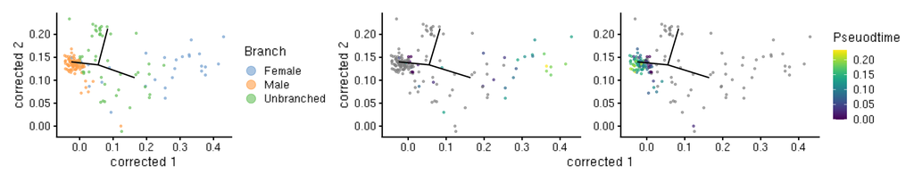

```r
line.data.sub_corrected = line.data_corrected[grepl("^14--", line.data_corrected$edge) | grepl("--14$", line.data_corrected$edge),]
line.data.sub_corrected <- line.data.sub_corrected[grepl("--1", line.data.sub_corrected$edge) | grepl("--13", line.data.sub_corrected$edge),]

ggline_corrected <- geom_line(data=line.data.sub_corrected, mapping=aes(x=dim1, y=dim2, group=edge))

ps = pathStat(pseudo14$ordering)

# cells on female path
pathF = rownames(ps)[!is.na(ps[,3])]
# cells on male path
pathM = rownames(ps)[!is.na(ps[,2])]
# cells that haven't yet branched
pathUB = rownames(ps)[!is.na(ps[,1])]

pathF = pathF[!pathF %in% pathUB]
pathM = pathM[!pathM %in% pathUB]

coldat = as.data.frame(colData(merged.sex.sce14))
coldat$CellId = rownames(coldat)

coldat =
  coldat %>%
  mutate(CellPath = case_when(
    CellId %in% pathF ~ "Female",
    CellId %in% pathM ~ "Male",
    CellId %in% pathUB ~ "Unbranched",
  ))

merged.sex.sce14$Branch = coldat$CellPath

path_plot = plotTSNE(merged.sex.sce14, dimred = "corrected", colour_by="Branch", point_size = .5) + ggline_corrected + guides(color = guide_legend(override.aes = list(size=3)))

merged.sex.sce14$Pseuodtime = coldat$TSCAN.2

fplot = plotTSNE(merged.sex.sce14, dimred = "corrected", colour_by="Pseuodtime", point_size = .5) + ggline_corrected

merged.sex.sce14$Pseuodtime = coldat$TSCAN.8

mplot = plotTSNE(merged.sex.sce14, dimred = "corrected", colour_by="Pseuodtime", point_size = .5) + ggline_corrected


path_plot + (fplot + mplot +  plot_layout(guides = "collect", axis_titles = "collect")) + plot_layout(widths = c(.8,2))
```

```r
pseudo_test2 <- testPseudotime(combined.sex.sce14, df=1, pseudotime=combined.sex.sce14$TSCAN.2)
```

```r
pseudo_test8 <- testPseudotime(combined.sex.sce14, df=1, pseudotime=combined.sex.sce14$TSCAN.8)
```

We want to find genes that are significant in path 2 and are not significant and/or changing in the opposite direction in path 8 and vise versa. We use the raw p-values to look for non-significant genes in order to increase the stringency of the definition of unique genes in our path.

## Genes uniquely changing on path 2 vs 8

These are saved in `results/no.support_sex_only2_DEgenes.csv`.

```r
only2 <- pseudo_test2[which(pseudo_test2$FDR <= 0.05 &
    (pseudo_test8$p.value >= 0.05 | sign(pseudo_test2$logFC)!=sign(pseudo_test8$logFC))),]

only2 = as.data.frame(only2)
only2$Gene = rownames(only2)
only2 = left_join(only2, gene_description, by = "Gene")
only2 = only2[c(4,5,6,1,2,3)]

write.csv(only2, file = paste0(results_dir, "/no.support_sex_only2_DEgenes.csv"), row.names = FALSE)

datatable(only2[order(only2$p.value),], filter="top", rownames = FALSE)
```

| Gene | WangGeneID | description | logFC | p.value | FDR |
| --- | --- | --- | --- | --- | --- |
| LOC116947087 | S100A1-6 | protein S100-A1-like | 28.08824422750144 | 1.51189889759003e-06 | 0.01109081361245605 |
| LOC116947151 | S100A1-13 | protein S100-A1-like | 26.03797745999487 | 2.153223346747968e-06 | 0.01109081361245605 |
| LOC116947085 | S100A1-4 | protein S100-A1-like, transcript variant X1 | 28.44834538693953 | 2.56336216004377e-06 | 0.01109081361245605 |
| LOC116956881 | aep1.3 | aerolysin-like protein, transcript variant X3 | 24.06332182144173 | 5.232574949814215e-06 | 0.01377063784457715 |
| LOC116942075 | S100P | protein S100-P-like | 15.31321354138117 | 6.733637118255485e-06 | 0.01377063784457715 |
| LOC116941108 | GJC1.11 | gap junction gamma-1 protein-like, transcript variant X3 | 9.321904338085101 | 6.846004982478015e-06 | 0.01377063784457715 |
| LOC116956115 | ZPLD1-3 | ZP domain-containing protein-like | 21.98161730846658 | 7.426384045611714e-06 | 0.01377063784457715 |
| LOC116956100 | CUZD1.4 | CUB and zona pellucida-like domain-containing protein 1 | 25.28226603523678 | 8.746755982631678e-06 | 0.0141916115818199 |
| LOC116947143 | S100A1-10 | protein S100-A1-like | 26.97994374332908 | 9.926852438867569e-06 | 0.01431672718405567 |
| LOC116947457 | protein B4 | protein B4 | 20.79832993552701 | 1.645703573783283e-05 | 0.02136123238770701 |

[output cut: 4 more lines]

### Top 50 heatmap

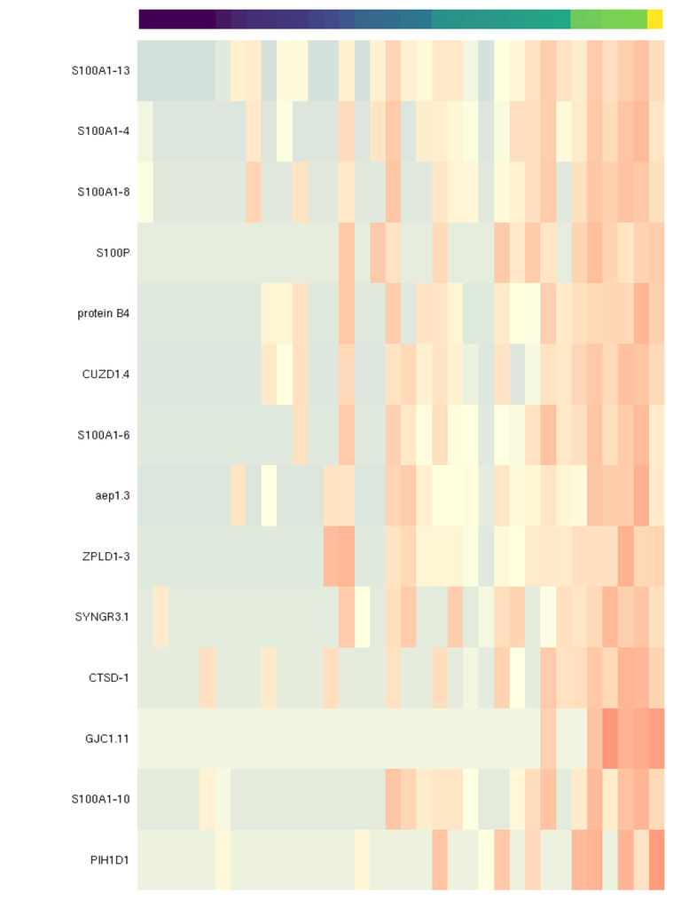

```r
on.path2 <- !is.na(combined.sex.sce14$TSCAN.2)

gene_description = as.data.frame(gene_description)
rownames(gene_description) = gene_description$Gene

gene_description = gene_description[rownames(combined.sex.sce14),]

rowData(combined.sex.sce14) = gene_description
combined.sex.sce14$Pseudotime = coldat$TSCAN.2

top50 =
  only2 %>%
  slice_min(order_by = FDR, n=50) %>%
  pull(Gene) %>%
  unique()

top50_wang =
  only2 %>%
  slice_min(order_by = FDR, n=50) %>%
  pull(WangGeneID) %>%
  unique()

# -------------------------------------------
# 1. Expression matrix centered
# -------------------------------------------
mat <- logcounts(combined.sex.sce14[top50,on.path2])
rownames(mat) = top50_wang
mat_scaled <- t(scale(t(mat), center = TRUE))

min_f =min(mat_scaled)
max_f = max(mat_scaled)

# -------------------------------------------
# 2. Metadata + ordering by label
# -------------------------------------------
meta <- as.data.frame(colData(combined.sex.sce14[,on.path2]))
meta <- meta %>% arrange(TSCAN.2)
mat_scaled <- mat_scaled[, rownames(meta)]

# -------------------------------------------
# 3. Cluster genes
# -------------------------------------------
gene_dist <- dist(mat_scaled)
gene_clust <- hclust(gene_dist, method = "ward.D2")
gene_order <- gene_clust$labels[gene_clust$order]
mat_scaled <- mat_scaled[gene_order, , drop = FALSE]

# -------------------------------------------
# 4. Long data
# -------------------------------------------
library(tibble)

df_long <- as.data.frame(mat_scaled) %>%
  rownames_to_column("Gene") %>%
  tidyr::pivot_longer(-Gene, names_to = "Cell", values_to = "Expression") %>%
  left_join(meta %>% tibble::rownames_to_column("Cell"), by = "Cell")

df_long$Gene <- factor(df_long$Gene, levels = gene_order)
meta$Cell <- as.character(rownames(meta))

# -------------------------------------------
# 6. Annotation bar
# -------------------------------------------

meta$Cell <- factor(meta$Cell, levels = meta$Cell)

f_anno_bar <- ggplot(meta, aes(x = Cell, y = 1, fill = Pseudotime)) +
  geom_tile() +
  scale_fill_viridis_c(option = "viridis",
                       na.value = "white",
                       guide = "none")  +
  theme_minimal(base_size = 10) +
  theme(
    legend.position = "right",
    axis.text.x = element_blank(),
    axis.ticks.x = element_blank(),
    axis.text.y = element_blank(),
    axis.ticks.y = element_blank(),
    axis.title = element_blank(),
    panel.grid = element_blank(),
    panel.background = element_rect(fill = "white", color = NA),
    plot.margin = margin(0, 5, 0, 40)
  ) + labs(fill = "Pseudotime")

# -------------------------------------------
# 7. Heatmap
# -------------------------------------------
df_long$Cell <- factor(df_long$Cell, levels = meta$Cell)

f_heatmap_plot <-
  ggplot(df_long, aes(x = Cell, y = Gene, fill = Expression)) +
  geom_tile() +
  scale_fill_gradient2(low = "steelblue3",
                      mid =  "#FFFFE0",
                      high = "firebrick2",
                      midpoint = 0,
                      na.value = "white",
                      limits = c(-4,5),
                      guide = "none") +
  scale_x_discrete(expand = c(0, 0)) +
  theme_minimal(base_size = 10) +
  theme(
    axis.text.x = element_blank(),
    axis.ticks.x = element_blank(),
    axis.text.y = element_text(size = 7,
                               color = "black",
                               face = "italic",
                               family = "sans"),
    panel.grid = element_blank(),
    axis.title = element_blank(),
    plot.margin = margin(0, 5, 0, 40),
  ) + labs(fill = "Scaled\nexpression")

# -------------------------------------------
# 9. Combine
# -------------------------------------------
f_anno_bar / f_heatmap_plot + plot_layout(heights = c(0.025, 1), guides = "collect")
```

```r
# ggsave(paste0(results_dir, "/test.png"),
#         height = 9,
#         width = 6)
```

## Gene ontology enrichment of genes uniquely changing on path 2 vs 8

**Columns**

- `GOID`: Gene ontology ID
- `GOName`: Gene ontology name
- `nGOTermGenes`: Number of genes assigned to GO term
- `Path`: Path and whether the gene is up or down regulated
- `nPathDEGenes`: Number of genes differentially expressed on the path
- `nSharedGenes`: Number of shared genes between the GO term and path DE genes
- `Pval`: p-value
- `FDR`: p-value corrected for multiple comparisons

These results are save in `results/no.support_sex_only2_gene_GO_pvals.csv`. Overlapping genes are save in `results/no.support_sex_only2_gene_GO_overlaps.csv`

```r
gaf = read.delim("/mnt/research/bioinformaticsCore/shared/Genomes/Petromyzon_marinus/GCF_010993605.1_kPetMar1.pri_gene_ontology.gaf", header=F, comment = "!")

gaf <-
  gaf %>%
  filter(!grepl("NOT", V4)) %>%
  dplyr::select(V3, V5) %>%
  dplyr::rename(GOID = "V5",
                Gene = "V3") %>%
  distinct()

keep_go =
  gaf %>%
  group_by(GOID) %>%
  tally() %>%
  filter(n > 10,
         n < 200) %>%
  pull(GOID)

gaf =
  gaf %>%
  filter(GOID %in% keep_go)

go_names = read.delim("/mnt/research/bioinformaticsCore/shared/Genomes/Petromyzon_marinus/GOs_names.txt", header = F)
colnames(go_names) = c("GOID", "GOName")

only2_genes =
  only2 %>%
  mutate(Path = case_when(
    logFC > 0 ~ "Only2.Upregulated",
    logFC < 0 ~  "Only2.Downregulated")
    ) %>%
  select(Gene, Path)


go_ol =  phyperOverlapSets(gaf,
                           only2_genes, length(merged.sex.sce))

shared_gene_description =
  gene_description %>%
  dplyr::rename(SharedGene = "Gene")

go_ol$intersecting.genes =
  go_ol$intersecting.genes %>%
  left_join(shared_gene_description, by="SharedGene")

write.csv(go_ol$intersecting.genes, file = paste0(results_dir, "/no.support_sex_only2_gene_GO_overlaps.csv"), row.names = FALSE)

scores = go_ol$pval.scores

scores =
  scores %>%
  dplyr::rename(GOID = "Group1",
                Path = "Group2",
                nGOTermGenes = "nGroup1",
                nPathDEGenes = "nGroup2") %>%
    mutate(FDR = p.adjust(Pval, "BH")) %>%
  select(-Enrichment)

scores =
  left_join(go_names, scores, by="GOID") %>%
  filter(!is.na(nGOTermGenes)) %>%
  filter(nSharedGenes > 0)

write.csv(scores, file = paste0(results_dir, "/no.support_sex_only2_gene_GO_pvals.csv"), row.names = FALSE)

datatable(scores %>% arrange(desc(nSharedGenes)), filter = "top", rownames = FALSE)
```

| GOID | GOName | nGOTermGenes | Path | nPathDEGenes | nSharedGenes | Pval | FDR |
| --- | --- | --- | --- | --- | --- | --- | --- |
| GO:0006334 | nucleosome assembly | 15 | Only2.Upregulated | 14 | 1 | 0.04124334932070006 | 1 |
| GO:0006364 | rRNA processing | 35 | Only2.Upregulated | 14 | 1 | 0.0937799661223292 | 1 |
| GO:0007154 | cell communication | 56 | Only2.Upregulated | 14 | 1 | 0.1460573266737235 | 1 |

## Genes uniquely changing on path 8 vs 2

These are saved in `results/no.support_sex_only8_DEgenes.csv`.

```r
only8 <- pseudo_test8[which(pseudo_test8$FDR <= 0.05 &
    (pseudo_test2$p.value >= 0.05 | sign(pseudo_test2$logFC)!=sign(pseudo_test8$logFC))),]

only8 = as.data.frame(only8)
only8$Gene = rownames(only8)
only8 = left_join(only8, gene_description, by = "Gene")
only8 = only8[c(4,5,6,1,2,3)]

write.csv(only8, file = paste0(results_dir, "/no.support_sex_only8_DEgenes.csv"), row.names = FALSE)

datatable(only8[order(only8$p.value),], filter="top", rownames = FALSE)
```

| Gene | WangGeneID | description | logFC | p.value | FDR |
| --- | --- | --- | --- | --- | --- |
| LOC116952389 | LOC116952389 | uncharacterized LOC116952389, transcript variant X1 | -14.98112278976854 | 6.924935539145136e-09 | 3.192203920352789e-05 |
| LOC116953100 | LOC116953100 | protein disulfide-isomerase-like | -22.21789718521936 | 7.875665010430615e-09 | 3.192203920352789e-05 |
| LOC116938960 | DR1-2 | protein Dr1-like, transcript variant X1 | -19.67623169828242 | 1.635189252870156e-08 | 3.672680251573068e-05 |
| LOC116937082 | LOC116937082 | inference COORDINATES: nucleotide motif:Rfam:12.0:RF02543 | -22.65350714766591 | 1.652739873410463e-08 | 3.672680251573068e-05 |
| LOC116937381 | COP0 | E3 ubiquitin-protein ligase COP1-like | -17.27776567416763 | 1.812215013420375e-08 | 3.672680251573068e-05 |
| LOC116951578 | globin-1-like.3 | globin-1-like | -23.00499961467476 | 2.113249011210563e-08 | 3.806900690972984e-05 |
| LOC116939016 | LOC116939016 | exosome component 10-like | -16.41465771121539 | 5.626596652106103e-08 | 7.602000960049686e-05 |
| LOC116947610 | LOC116947610 | uncharacterized LOC116947610 | 14.69837578709557 | 7.959096848195487e-08 | 8.424828816970424e-05 |
| LOC116937078 | LOC116937078 | uncharacterized LOC116937078 | -24.09039687317862 | 8.597322317093637e-08 | 8.424828816970424e-05 |
| LOC116957215 | LOC116957215 | model_evidence Supporting evidence includes similarity to: 404 Proteins, and 34% coverage of the annotated genomic feature by RNAseq alignments | -17.9397696324574 | 8.83378090967108e-08 | 8.424828816970424e-05 |

[output cut: 842 more lines]

### Top 50 heatmap

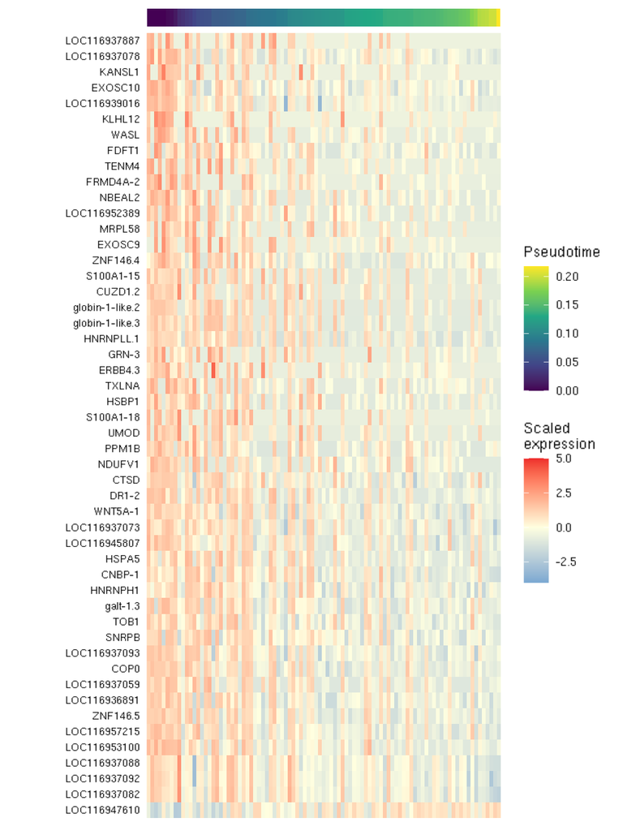

```r
on.path8 <- !is.na(combined.sex.sce14$TSCAN.8)

gene_description = as.data.frame(gene_description)
rownames(gene_description) = gene_description$Gene

gene_description = gene_description[rownames(combined.sex.sce14),]

rowData(combined.sex.sce14) = gene_description
combined.sex.sce14$Pseudotime = coldat$TSCAN.8

top50 =
  only8 %>%
  slice_min(order_by = FDR, n=50) %>%
  pull(Gene) %>%
  unique()

top50_wang =
  only8 %>%
  slice_min(order_by = FDR, n=50) %>%
  pull(WangGeneID) %>%
  unique()

# -------------------------------------------
# 1. Expression matrix centered
# -------------------------------------------
mat <- logcounts(combined.sex.sce14[top50,on.path8])
rownames(mat) = top50_wang
mat_scaled <- t(scale(t(mat), center = TRUE))

min_m = min(mat_scaled)
max_m = max(mat_scaled)

# -------------------------------------------
# 2. Metadata + ordering by label
# -------------------------------------------
meta <- as.data.frame(colData(combined.sex.sce14[,on.path8]))
meta <- meta %>% arrange(TSCAN.8)
mat_scaled <- mat_scaled[, rownames(meta)]

# -------------------------------------------
# 3. Cluster genes
# -------------------------------------------
gene_dist <- dist(mat_scaled)
gene_clust <- hclust(gene_dist, method = "ward.D2")
gene_order <- gene_clust$labels[gene_clust$order]
mat_scaled <- mat_scaled[gene_order, , drop = FALSE]

# -------------------------------------------
# 4. Long data
# -------------------------------------------
library(tibble)

df_long <- as.data.frame(mat_scaled) %>%
  rownames_to_column("Gene") %>%
  tidyr::pivot_longer(-Gene, names_to = "Cell", values_to = "Expression") %>%
  left_join(meta %>% tibble::rownames_to_column("Cell"), by = "Cell")

df_long$Gene <- factor(df_long$Gene, levels = gene_order)
meta$Cell <- as.character(rownames(meta))

# -------------------------------------------
# 6. Annotation bar
# -------------------------------------------

meta$Cell <- factor(meta$Cell, levels = meta$Cell)

m_anno_bar <- ggplot(meta, aes(x = Cell, y = 1, fill = Pseudotime)) +
  geom_tile() +
  scale_fill_viridis_c(option = "viridis",
                       na.value = "white")  +
  theme_minimal(base_size = 10) +
  theme(
    legend.position = "right",
    axis.text.x = element_blank(),
    axis.ticks.x = element_blank(),
    axis.text.y = element_blank(),
    axis.ticks.y = element_blank(),
    axis.title = element_blank(),
    panel.grid = element_blank(),
    panel.background = element_rect(fill = "white", color = NA),
    plot.margin = margin(0, 5, 0, 40)
  ) + labs(fill = "Pseudotime")

# -------------------------------------------
# 7. Heatmap
# -------------------------------------------
df_long$Cell <- factor(df_long$Cell, levels = meta$Cell)

m_heatmap_plot <-
  ggplot(df_long, aes(x = Cell, y = Gene, fill = Expression)) +
  geom_tile() +
  scale_fill_gradient2(low = "steelblue3",
                      mid =  "#FFFFE0",
                      high = "firebrick2",
                      midpoint = 0,
                      na.value = "white",
                      limits = c(-4,5)) +
  scale_x_discrete(expand = c(0, 0)) +
  theme_minimal(base_size = 10) +
  theme(
    axis.text.x = element_blank(),
    axis.ticks.x = element_blank(),
    axis.text.y = element_text(size = 7,
                               color = "black",
                               face = "italic",
                               family = "sans"),
    panel.grid = element_blank(),
    axis.title = element_blank(),
    plot.margin = margin(0, 5, 0, 40),
  ) + labs(fill = "Scaled\nexpression")

# -------------------------------------------
# 9. Combine
# -------------------------------------------
m_anno_bar / m_heatmap_plot + plot_layout(heights = c(0.025, 1), guides = "collect")
```

```r
# ggsave(paste0(results_dir, "/test.png"),
#         height = 9,
#         width = 6)
```

## Gene ontology enrichment of genes uniquely changing on path 8 vs 2

**Columns**

- `GOID`: Gene ontology ID
- `GOName`: Gene ontology name
- `nGOTermGenes`: Number of genes assigned to GO term
- `Path`: Path and whether the gene is up or down regulated
- `nPathDEGenes`: Number of genes differentially expressed on the path
- `nSharedGenes`: Number of shared genes between the GO term and path DE genes
- `Pval`: p-value
- `FDR`: p-value corrected for multiple comparisons

These results are save in `results/no.support_sex_only8_gene_GO_pvals.csv`. Overlapping genes are save in `results/no.support_sex_only8_gene_GO_overlaps.csv`

```r
only8_genes =
  only8 %>%
  mutate(Path = case_when(
    logFC > 0 ~ "Only8.Upregulated",
    logFC < 0 ~  "Only8.Downregulated")
    ) %>%
  select(Gene, Path)


go_ol =  phyperOverlapSets(gaf,
                           only8_genes, length(merged.sex.sce))


shared_gene_description =
  gene_description %>%
  dplyr::rename(SharedGene = "Gene")

go_ol$intersecting.genes =
  go_ol$intersecting.genes %>%
  left_join(shared_gene_description, by="SharedGene")

write.csv(go_ol$intersecting.genes, file = paste0(results_dir, "/no.support_sex_only8_gene_GO_overlaps.csv"), row.names = FALSE)

scores = go_ol$pval.scores

scores =
  scores %>%
  dplyr::rename(GOID = "Group1",
                Path = "Group2",
                nGOTermGenes = "nGroup1",
                nOnly8DEGenes = "nGroup2") %>%
    mutate(FDR = p.adjust(Pval, "BH")) %>%
  select(-Enrichment)

scores =
  left_join(go_names, scores, by="GOID") %>%
  filter(!is.na(nGOTermGenes)) %>%
  filter(nSharedGenes > 0)

write.csv(scores, file = paste0(results_dir, "/no.support_sex_only8_gene_GO_pvals.csv"), row.names = FALSE)

datatable(scores %>% arrange(desc(nSharedGenes)), filter = "top", rownames = FALSE)
```

| GOID | GOName | nGOTermGenes | Path | nOnly8DEGenes | nSharedGenes | Pval | FDR |
| --- | --- | --- | --- | --- | --- | --- | --- |
| GO:0043484 | regulation of RNA splicing | 29 | Only8.Downregulated | 833 | 13 | 0.0003435192507255055 | 0.1166591375463817 |
| GO:0006355 | regulation of DNA-templated transcription | 178 | Only8.Downregulated | 833 | 12 | 0.999980614570235 | 1 |
| GO:0006886 | intracellular protein transport | 142 | Only8.Downregulated | 833 | 11 | 0.9994734426458292 | 1 |
| GO:0007275 | multicellular organism development | 158 | Only8.Downregulated | 833 | 9 | 0.9999933088142642 | 1 |
| GO:0006397 | mRNA processing | 31 | Only8.Downregulated | 833 | 8 | 0.1310728477988011 | 1 |
| GO:0007169 | cell surface receptor protein tyrosine kinase signaling pathway | 83 | Only8.Downregulated | 833 | 8 | 0.9765542622856371 | 1 |
| GO:0007411 | axon guidance | 81 | Only8.Downregulated | 833 | 8 | 0.9711712064032433 | 1 |
| GO:0016192 | vesicle-mediated transport | 83 | Only8.Downregulated | 833 | 8 | 0.9765542622856371 | 1 |
| GO:0016579 | protein deubiquitination | 56 | Only8.Downregulated | 833 | 8 | 0.7377725565752813 | 1 |
| GO:0006470 | protein dephosphorylation | 112 | Only8.Downregulated | 833 | 7 | 0.9997482702931908 | 1 |

[output cut: 238 more lines]

# Figures

```r
## Add cluster annotations
#All Cells
anno_all = c("1. Interstitial stromal cells",
             "2. Mesonephric stromal cells",
             "3. Granulosa cells",
             "4. Leydig cells",
             "5. Primordial germ cells/oogonia",
             "6. Endothelial cells",
             "7. Mesonephric cells",
             "8. Erythrocytes",
             "9. Sertoli cells",
             "10. B lymphocytes",
             "11. Hemopoietic stem cells",
             "12. Mesonephric podocytes",
             "13. Macrophages",
             "14. Proliferating pre-granulosa cells",
             "15. Proliferating B cells",
             "16. Meiotic spermatocyte",
             "17. Spermatocyte",
             "18. Mitotic spermatogonia ",
             "19. Migrating male germ cells")

ct = anno_all[colData(merged.sce)$label]
merged.sce$CellType = ct
merged.sce$CellType = factor(merged.sce$CellType, levels= anno_all)

combined.sce$CellType = ct
combined.sce$CellType = factor(combined.sce$CellType, levels= anno_all)

scatter.clusters = as.data.frame(colData(merged.sce))
scatter.clusters$barcode = rownames(scatter.clusters)

scatter.clusters =
  scatter.clusters %>%
  select(barcode, label) %>%
  tibble::deframe()

scatter.clusters = scatter.clusters[colnames(combined.sce)]
combined.sce$label = scatter.clusters
```

```r
# Sex cells
anno =
  c("1. oogonia",
    "2. oogonia",
    "3. oogonia",
    "4. meiotic spermatocyte",
    "5. spermatocyte",
    "6. migrating male GC/spermatocyte",
    "7. mitotic spermatogonia",
    "8. migrating male GC/spermatocyte",
    "9. spermatocyte",
    "10. spermatocyte/mitotic spermatogonia",
    "11. mitotic spermatogonia",
    "12. spermatocyte",
    "13. migrating GC cells",
    "14. PCG/spermatocyte",
    "15. PCG"
    )


ct = anno[colData(merged.sex.sce)$label]
merged.sex.sce$CellType = ct
merged.sex.sce$CellType = factor(merged.sex.sce$CellType, levels= anno)

combined.sex.sce$CellType = ct
combined.sex.sce$CellType = factor(combined.sex.sce$CellType, levels= anno)

scatter.clusters = as.data.frame(colData(merged.sex.sce))
scatter.clusters$barcode = rownames(scatter.clusters)

scatter.clusters =
  scatter.clusters %>%
  select(barcode, label) %>%
  tibble::deframe()

scatter.clusters = scatter.clusters[colnames(combined.sex.sce)]
combined.sex.sce$label = scatter.clusters
```

```r
goi_long = c("BOLL", "LOC116955069", "CHEK2", "DDX4",
              "LOC116946948","LOC116952239","HSD11B1L",
              "LOC116944806","LOC116945518", "LOC116952716","NANOS1",
              "PAX2","PAX7","LOC116939357",
              "PIWIL1","POU2F2","LOC116944884","SFRP2",
              "LOC103091769","TRIP4","LOC116955055",
              "LOC116950388","CFAP69","LOC103091770",
              "LOC116948775","LOC103091860","LOC103091810",
              "LOC116940926","LOC116948663","KDM1A",
              "PEG10","SCFD1","SPAG5","SPAG16",
              "SPATA22","TEX11","LOC116950791","WNT11",
              "ZAR1L")
```

## Supplemental violin plots

### Violin plots – all cells

```r
# Violin plots -- all cells

combined.sce.plot = combined.sce[goi_long,]

goi_names =
  gene_description %>%
  filter(Gene %in% goi_long) %>%
  pull(WangGeneID)

rownames(combined.sce.plot) = goi_names

goi_names_alph = goi_names[order(goi_names)]

plot_config <- data.frame(
  start = c(1, 8, 15, 22, 28, 36),
  end = c(7, 14, 21, 29, 35, 39),
  height = c(10, 10, 10, 10, 10, 6)
)

for (i in 1:nrow(plot_config)) {
  p <- scater::plotExpression(combined.sce.plot,
                              x = "label",
                              colour_by = "CellType",
                              features = goi_names_alph[plot_config$start[i]:plot_config$end[i]],
                              assay.type = "logcounts",
                              scales = "free_y",
                              ncol = 1,
                              point_size = .5,
                              scattermore = TRUE) +
    theme(axis.text.x = element_text(size = 6)) +
    guides(color = guide_legend(override.aes = list(size = 3)))

  ggsave(filename = paste0(results_dir, "/all_cells_vln", i, ".png"),
         plot = p,
         width = 8,
         height = plot_config$height[i])
}
```

### Violin plots – sex cells

```r
# Violin plots -- sex cells
combined.sex.sce.plot = combined.sex.sce[goi_long,]

goi_names =
  gene_description %>%
  filter(Gene %in% goi_long) %>%
  select(Gene, WangGeneID) %>%
  deframe()

goi_names = goi_names[goi_long]

rownames(combined.sex.sce.plot) = goi_names

goi_names_alph = goi_names[order(goi_names)]

for (i in 1:nrow(plot_config)) {
  p <- scater::plotExpression(combined.sex.sce.plot,
                              x = "label",
                              colour_by = "CellType",
                              features = goi_names_alph[plot_config$start[i]:plot_config$end[i]],
                              assay.type = "logcounts",
                              scales = "free_y",
                              ncol = 1,
                              point_size = .5,
                              scattermore = TRUE) +
    theme(axis.text.x = element_text(size = 6)) +
    guides(color = guide_legend(override.aes = list(size = 3)))

  ggsave(filename = paste0(results_dir, "/sex_cells_vln", i, ".png"),
         plot = p,
         width = 8,
         height = plot_config$height[i])
}
```

## Figure 1. Cell type identification in lamprey gonadal single-cell RNA-seq data.

```r
all_tsne = plotTSNE(merged.sce, colour_by="CellType", point_size = .05) +
  guides(color = guide_legend(override.aes = list(size=5)))
```

```r
library(tibble)
goi_short_wang = c("BOLL", "CSF1R", "CHEK2", "DDX4",
                   "FOXL2","GATA2-3","HSD11B1L",
                   "LHX8","LYVE1", "LYZ","NANOS1",
                   "PAX2","PAX7","PDGFRA",
                   "PIWIL1","POU2F2","PTPRC","SFRP2",
                   "sox9-a","TRIP4","FLT1-1",
                   "WNT4")

goi_short =
  gene_description %>%
  filter(WangGeneID %in% goi_short_wang) %>%
  select(WangGeneID, Gene) %>%
  deframe()
```

```r
# bubble
sce = combined.sce
goi = goi_long

sce.plot = sce[goi,]

goi_names =
  gene_description %>%
  filter(Gene %in% goi) %>%
  select(Gene, WangGeneID) %>%
  deframe()

goi_names = goi_names[goi]

rownames(sce.plot) = goi_names

mat <- logcounts(sce.plot)
mat = as.matrix(mat)

meta <- as.data.frame(colData(sce.plot))
meta <- meta %>% arrange(label)

df_long <- as.data.frame(mat) %>%
  rownames_to_column("Gene") %>%
  tidyr::pivot_longer(-Gene, names_to = "Cell", values_to = "Expression") %>%
  left_join(meta %>% tibble::rownames_to_column("Cell"), by = "Cell") %>%
  select(Gene, Cell, CellType, Expression)

markers = read.csv(paste0(results_dir, "/scatter_cluster_marker_genes.csv"), row.names = 1)

cluster_index = as.numeric(gsub("cluster_","",markers$cluster))
markers$CellType = anno_all[cluster_index]

markers =
  markers %>%
  select(WangGeneID, CellType, FDR, summary.logFC) %>%
  dplyr::rename(Gene = "WangGeneID")

plot_data <- df_long %>%
  group_by(Gene, CellType) %>%
  summarize(
    percent_expressed = mean(Expression > 0) * 100,
    avg_expression = mean(Expression[Expression > 0], na.rm = TRUE),
    .groups = "drop"
  ) %>%
  group_by(Gene) %>%
  mutate(
    scaled_expression = scale(avg_expression)[,1]  # Z-score by gene
  ) %>%
  ungroup() %>%
  mutate(
    text_color = ifelse(avg_expression > 5,
                       "black", "white")
  ) %>%
  left_join(markers)


percent_cells =
  df_long %>%
  group_by(Gene, CellType) %>%
  summarize(
    percent_expressing = mean(Expression > 0) * 100,
    n_cells = n(),
    n_expressing = sum(Expression > 0),
    .groups = "drop"
  )

percent_cells_wide =
  plot_data %>%
  tidyr::pivot_wider(id_cols = "Gene",
                     names_from="CellType",
                     values_from = "percent_expressed")

gene_rows = percent_cells_wide$Gene
percent_cells_wide$Gene = NULL
percent_cells_mat = as.matrix(percent_cells_wide)
rownames(percent_cells_mat) = gene_rows

if(length(goi) > 2){
  gene_dist <- dist(percent_cells_mat)
  gene_clust <- hclust(gene_dist, method = "ward.D2")
  gene_order <- gene_clust$labels[gene_clust$order]
  percent_cells$Gene = factor(percent_cells$Gene, levels = gene_order)
  plot_data$Gene = factor(plot_data$Gene, levels = gene_order)
}

# Create bubble plot
plot_data$CellType = factor(plot_data$CellType, levels = anno_all)

library(ggnewscale)

bubble =
  ggplot(plot_data, aes(x = CellType, y = Gene)) +
  geom_point(aes(size = percent_expressed, color = avg_expression)) +
  scale_size_continuous(
    name = "% Expressed",
    range = c(1, 5)  # min and max bubble size
  ) +
  scale_color_viridis_c(option = "C",
                        name = "Avg Expression") +
  new_scale_color() +
  geom_text(
    data = plot_data %>% filter(FDR<.01, summary.logFC > 0.5),
    aes(label = "*", color = text_color),
    size = 2,
    vjust = 0.6,
    show.legend = FALSE
  ) +
  scale_color_identity() +
  theme_minimal() +
  theme(
    axis.text.x = element_blank(),
    axis.title.x = element_blank(),
    legend.key.size = unit(0.5, "cm"),
    axis.text.y = element_text(size = 7,
                               color = "black",
                               face = "italic",
                               family = "sans"),
  )


# -------------------------------------------
# 6. Colors
# -------------------------------------------

all_label_colors = c("#1F77B4", "#AEC7E8", "#FF7F0E", "#FFBB78",
                     "#2CA02C", "#98DF8A", "#D62728", "#FF9896",
                     "#9467BD", "#C5B0D5", "#8C564B", "#C49C94",
                     "#E377C2", "#F7B6D2", "#7F7F7F", "#C7C7C7",
                     "#BCBD22", "#DBDB8D", "#17BECF")

label_colors = all_label_colors[1:length(unique(percent_cells$CellType))]

names(label_colors) = unique(percent_cells$CellType)

# -------------------------------------------
# 7. Annotation bar
# -------------------------------------------

anno_bar <- ggplot(percent_cells, aes(x = CellType, y = 1, fill = CellType)) +
  geom_tile() +
  scale_fill_manual(values = c(label_colors, "NA" = "white"), na.value = "white", drop = FALSE) +
  scale_x_discrete(expand = c(0, 0)) +
  theme_minimal(base_size = 10) +
  theme(
    #legend.position = "none",
    legend.key.size = unit(.4, "cm"),
    legend.key.width = unit(.4, "cm"),
    axis.text.x = element_blank(),
    axis.ticks.x = element_blank(),
    axis.text.y = element_blank(),
    axis.ticks.y = element_blank(),
    axis.title = element_blank(),
    panel.grid = element_blank(),
    plot.margin = margin(0, 5, 0, 40)
  )
```

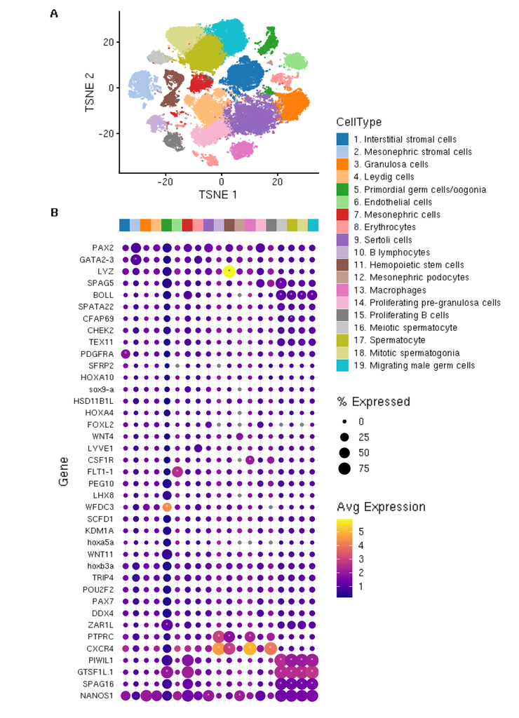

```r
all_tsne_tag =  all_tsne + labs(tag="A")  + theme(legend.position = "none")
anno_bar_tag = anno_bar + labs(tag="B")

free(all_tsne_tag,type = "label") /
  (anno_bar_tag / bubble + plot_layout(heights = c(0.03, 1))) +
  plot_layout(ncol =1, height =c(1,3), guides = "collect") &
  theme(plot.tag = element_text(size = 10, face="bold"))
```

```r
ggsave(file = paste0(results_dir, "/fig1_long.png"), width =6.5 ,height=9)
```

1. t-SNE visualization of all cells colored by annotated cell types. (B) Dot plot showing average expression of and percentage of cells expressing selected marker genes across identified cell types. The color scale represents average log-normalized expression across cells expressing the gene within a cell type, with yellow indicating high expression and blue indicating low expression. The size of each dot represents the percentage of cells expressing each gene within a cluster. An asterisk indicates the gene is significantly enriched in the cell-type (FDR < 0.01, log2 fold change > 0.50). In some cases, gene names are derived from homologous proteins from humans and other species as reported by Wang et al.

## Figure 2. Germ cell lineage trajectory shows progression from primordial germ cells to maturing oogonia and spermatocytes.

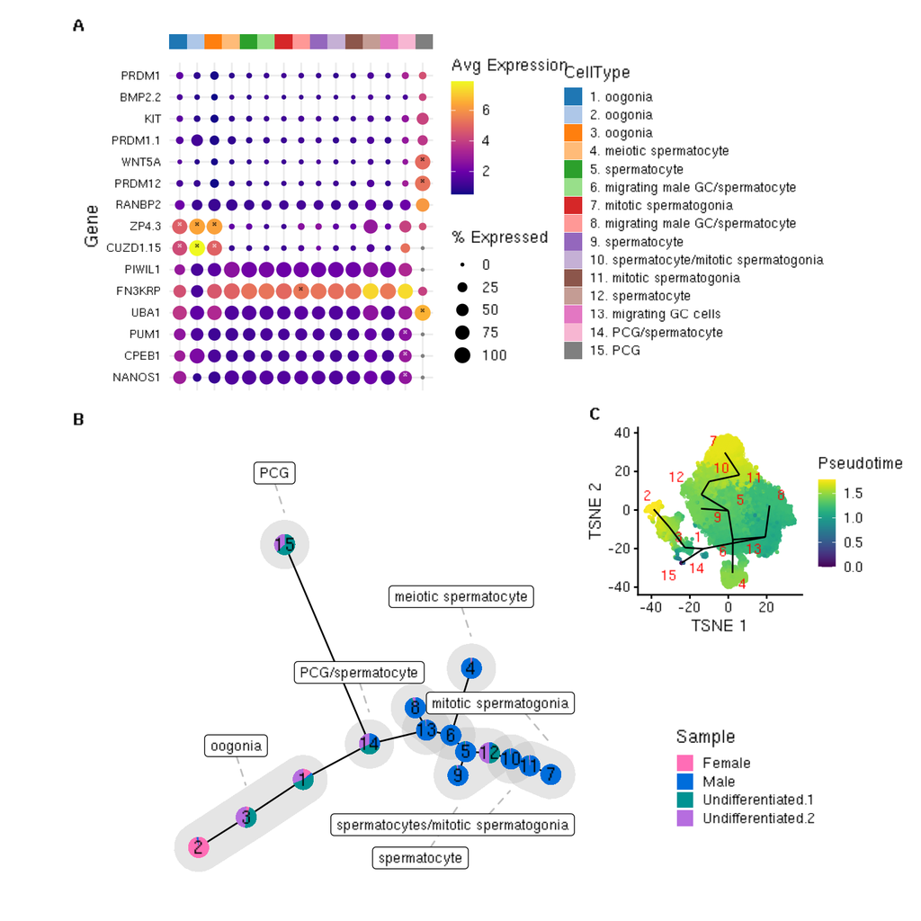

```r
library(cowplot)
library(grid)
library(gridExtra)
library(viridis)

#PGC = c("PRDM1","BMP2.2","PRDM1.1","TRRAP","RUNX1T1","WNT5A","PRDM12","UBA1","KIT","RANBP2", "NANOS1", "PUM1", "CPEB1")

PGC = c("PRDM1","BMP2.2","PRDM1.1","WNT5A","PRDM12","UBA1","KIT","RANBP2", "NANOS1", "PUM1", "CPEB1", "ZP4.3", "CUZD1.15", "PIWIL1", "FN3KRP")

sce = combined.sex.sce

library(tibble)
goi =
  gene_description %>%
  filter(WangGeneID %in% PGC) %>%
  select(WangGeneID, Gene) %>%
  deframe()

goi = goi[goi %in% rownames(sce)]

sce.plot = sce[goi,]

goi_names =
  gene_description %>%
  filter(Gene %in% goi) %>%
  select(Gene, WangGeneID) %>%
  deframe()

goi_names = goi_names[goi]

rownames(sce.plot) = goi_names

mat <- logcounts(sce.plot)
mat = as.matrix(mat)

meta <- as.data.frame(colData(sce.plot))
meta <- meta %>% arrange(label)

df_long <- as.data.frame(mat) %>%
  rownames_to_column("Gene") %>%
  tidyr::pivot_longer(-Gene, names_to = "Cell", values_to = "Expression") %>%
  left_join(meta %>% tibble::rownames_to_column("Cell"), by = "Cell") %>%
  select(Gene, Cell, CellType, Expression)

markers = read.csv(paste0(results_dir, "/no.support_sex_scatter_cluster_marker_genes.csv"), row.names = 1)

cluster_index = as.numeric(gsub("cluster_","",markers$cluster))
markers$CellType = anno[cluster_index]

markers =
  markers %>%
  select(WangGeneID, CellType, FDR, summary.logFC) %>%
  dplyr::rename(Gene = "WangGeneID")

plot_data <- df_long %>%
  group_by(Gene, CellType) %>%
  summarize(
    percent_expressed = mean(Expression > 0) * 100,
    avg_expression = mean(Expression[Expression > 0], na.rm = TRUE),
    .groups = "drop"
  ) %>%
  group_by(Gene) %>%
  mutate(
    scaled_expression = scale(avg_expression)[,1]  # Z-score by gene
  ) %>%
  ungroup() %>%
  mutate(
    text_color = ifelse(avg_expression > 5,
                       "black", "white")
  ) %>%
  left_join(markers)

percent_cells =
  df_long %>%
  group_by(Gene, CellType) %>%
  summarize(
    percent_expressing = mean(Expression > 0) * 100,
    n_cells = n(),
    n_expressing = sum(Expression > 0),
    .groups = "drop"
  )

percent_cells_wide =
  percent_cells %>%
  tidyr::pivot_wider(id_cols = "Gene",
                     names_from="CellType",
                     values_from = "percent_expressing")

gene_rows = percent_cells_wide$Gene
percent_cells_wide$Gene = NULL
percent_cells_mat = as.matrix(percent_cells_wide)
rownames(percent_cells_mat) = gene_rows

if(length(goi) > 2){
  gene_dist <- dist(percent_cells_mat)
  gene_clust <- hclust(gene_dist, method = "ward.D2")
  gene_order <- gene_clust$labels[gene_clust$order]
  percent_cells$Gene = factor(percent_cells$Gene, levels = gene_order)
  plot_data$Gene = factor(plot_data$Gene, levels = gene_order)

}


# -------------------------------------------
# 6. Colors
# -------------------------------------------

all_label_colors = c("#1F77B4", "#AEC7E8", "#FF7F0E", "#FFBB78",
                     "#2CA02C", "#98DF8A", "#D62728", "#FF9896",
                     "#9467BD", "#C5B0D5", "#8C564B", "#C49C94",
                     "#E377C2", "#F7B6D2", "#7F7F7F", "#C7C7C7",
                     "#BCBD22", "#DBDB8D", "#17BECF")

label_colors = all_label_colors[1:length(unique(percent_cells$CellType))]

names(label_colors) = unique(percent_cells$CellType)

# -------------------------------------------
# 7. Annotation bar
# -------------------------------------------

anno_bar <- ggplot(percent_cells, aes(x = CellType, y = 1, fill = CellType)) +
  geom_tile() +
  scale_fill_manual(values = c(label_colors, "NA" = "white"), na.value = "white", drop = FALSE) +
  scale_x_discrete(expand = c(0, 0)) +
  theme_minimal(base_size = 10) +
  theme(
    #legend.position = "none",
    legend.key.size = unit(.4, "cm"),
    legend.key.width = unit(.4, "cm"),
    axis.text.x = element_blank(),
    axis.ticks.x = element_blank(),
    axis.text.y = element_blank(),
    axis.ticks.y = element_blank(),
    axis.title = element_blank(),
    panel.grid = element_blank(),
    plot.margin = margin(0, 5, 0, 40)
  )
#+
#labs(title = names(list_of_dfs)[i])

# -------------------------------------------
# 8. Heatmap
# -------------------------------------------

plot_data$CellType = factor(plot_data$CellType, levels = anno)

library(ggnewscale)

bubble =
  ggplot(plot_data, aes(x = CellType, y = Gene)) +
  geom_point(aes(size = percent_expressed, color = avg_expression)) +
  scale_size_continuous(
    name = "% Expressed",
    range = c(.5, 4)  # min and max bubble size
  ) +
  scale_color_viridis_c(option = "C",
                        name = "Avg Expression") +
  new_scale_color() +
  geom_text(
    data = plot_data %>% filter(FDR<.01, summary.logFC > 0.5),
    aes(label = "*", color = text_color),
    size = 3,
    vjust = 0.6,
    show.legend = FALSE
  ) +
  scale_color_identity() +
  theme_minimal() +
  theme(
    axis.text.x = element_blank(),
    axis.title.x = element_blank(),
    legend.key.size = unit(0.5, "cm"),
    axis.text.y = element_text(size = 7,
                               color = "black",
                               face = "italic",
                               family = "sans"),
  )

# -------------------------------------------
# 9. Combine
# -------------------------------------------

anno_no_leg = anno_bar + theme(legend.position = "none") + labs(tag="A")
bubble_no_leg = bubble + theme(legend.position = "none")

gr_fixed <- gr_plot + coord_fixed(clip = "off") + theme(plot.margin = margin(0,0,0,0))
gr_fixed_no_leg = gr_fixed + theme(legend.position = "none") + labs(tag = "B")

pseudo_plot_tag = pseudo_plot + labs(tag = "C")

library(cowplot)

legend_anno = get_legend(anno_bar)

bubble =
  bubble + theme(legend.title = element_text(size = 10))

legend_bubble = get_legend(bubble)

legend_gr = get_plot_component(gr_plot, "guide-box", return_all = TRUE)[[2]]

main = anno_no_leg / bubble_no_leg + plot_layout(heights = c(0.05, 1))
leg = wrap_elements(legend_bubble) + wrap_elements(legend_anno) + plot_layout(widths = c(1,2))

top = (main | leg) + plot_layout(widths = c(1.5,2))

# bottom = (((pseudo_plot_tag / legend_gr)+plot_layout(heights = c(1,1.5))) | gr_fixed_no_leg) + plot_layout(widths = c(1,2.5))
bottom = (gr_fixed_no_leg | (pseudo_plot_tag / legend_gr)+plot_layout(heights = c(1,1.5))) + plot_layout(widths = c(2.5,1))

fig2 =
  top / bottom +
  plot_layout(heights = c(1.5,2)) &
  theme(plot.tag = element_text(size = 10, face="bold"))

ggsave(fig2, file = paste0(results_dir, "/fig2.png"), width = 8, height = 8)

fig2
```

## Figure 3. Sex-specific germ cell differentiation branch analysis

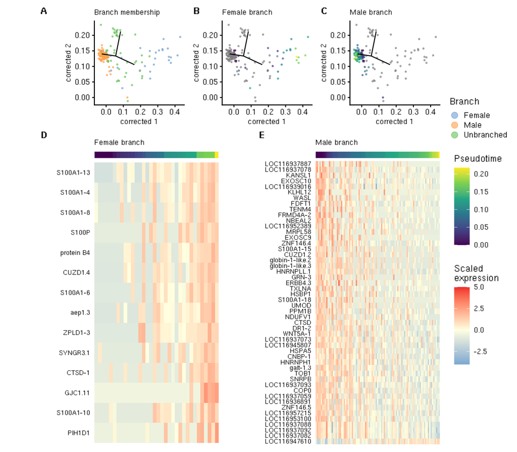

```r
path_tag = path_plot + labs(tag = "A", title = "Branch membership")

fplot_tag = fplot +
  labs(tag = "B", title = "Female branch") +
  theme(legend.position = "none")

mplot_tag = mplot +
  labs(tag = "C", title = "Male branch") +
  theme(legend.position = "none")

f_anno_tag = f_anno_bar + labs(tag = "D", title = "Female branch")

m_anno_tag = m_anno_bar + labs(tag = "E", title = "Male branch")

top = free(path_tag + fplot_tag + mplot_tag, type = "label") &
        theme(axis.title = element_text(size = 8))

bottom = (f_anno_tag / f_heatmap_plot + plot_layout(heights = c(0.025, 1))) |
(m_anno_tag / m_heatmap_plot + plot_layout(heights = c(0.025, 1)))

top / bottom +
  plot_layout(heights = c(1,3.5), guides = "collect") &
  theme(plot.tag = element_text(size = 10, face="bold"),
        plot.title = element_text(size = 8, face = "plain"))
```

```r
ggsave(file = paste0(results_dir, "/fig3.png"), width = 8, height=7)
```

A-C) Scatter plot of cluster 14 cells showing each cell’s branch assignment (A), pseudotime on the female-specific branch (B), and pseudotime on the male-specific branch (C). Cells are plotted in low-dimensional MNN-corrected space, with trajectories indicated by black lines. (D–E) Heatmaps showing scaled expression of the top genes uniquely associated with the female (D) and male (E) pseudotime trajectories. Each column represents an individual cell ordered by pseudotime progression, and each row corresponds to a gene. The color scale indicates relative expression (Z-score) across cells with red indicating high expression and blue indicating low expression. In some cases, gene names are derived from homologous proteins from humans and other species as reported by Wang et al.

# Clean SCEs with meta data

## All cells

pca and lognormcounts form individual samples

```r
combined.sce.final = combined.sce
combined.sce.final$Size_Factor = NULL
combined.sce.final$cluster = NULL
combined.sce.final$discard = NULL
saveRDS(combined.sce.final, paste0(results_dir, "/combined.sce.final.Rds"))

merged.sce.final = merged.sce
colData(merged.sce.final) = colData(combined.sce.final)
merged.sce.final$monocole_cluster = NULL
saveRDS(merged.sce.final, paste0(results_dir, "/merged.sce.final.Rds"))
```

## Germ cells

```r
merged.sex.sce.final = merged.sex.sce
merged.sex.sce.final$all.merged.clusters = NULL
merged.sex.sce.final$TSCAN.15 = NULL
merged.sex.sce.final$TSCAN.4 = NULL
merged.sex.sce.final$TSCAN.9 = NULL
merged.sex.sce.final$TSCAN.7 = NULL

merged.sex.sce.final$CommonPseudotime = merged.sex.sce.final$Pseudotime
merged.sex.sce.final$Pseudotime = NULL

merged.sex.sce.final$FemaleBranchPseudotime = merged.sex.sce.final$TSCAN.2
merged.sex.sce.final$MaleBranchPseudotime = merged.sex.sce.final$TSCAN.8
merged.sex.sce.final$TSCAN.2 = NULL
merged.sex.sce.final$TSCAN.8 = NULL
```